# Biological control of important fungal diseases of potato and raspberry by two *Bacillus velezensis* strains

Lourdes Arellano, Antonia Fernandes, Juliana Cajiao and Rosario Heribia

20/01/2022

```r
library(knitr)
knitr::opts_chunk$set(
  echo = TRUE,
  results = 'markup',
  fig.path = "results/",
  fig.width = 10,
  fig.height = 6.1803,
  dev = "png",
  dev.args = list(type = "cairo"),
  dpi = 100)
```

## Introduction

Fungal phytopathogens affect agricultural crops lead to a improtant decrease in their quality and production. They act as a threat to crops through various mechanisms of pathogenesis that compromise the immune system of the plants. The use of fungicides against fungal plant diseases improves crop yield, quality, and shelf-life (Brauer *et al*., 2019). Nevertheless, the irrational uses of this products triggers to health problems, and can also cause severe damage to the environment. Accumulation of pesticides in the environment disrupts the ecological balance and raises pathogen resistance to pesticides. Thus, the application of fungicides in agriculture should be under strict regulation to ensure that commercialized foods are safe for consumption and pose negligible risks of acute toxicity due to carry-over (Brauer *et al*., 2019).

In the case of potato and raspberry plants, they are affected by important diseases as stem canker and black scurf, causes by the fungi *Rhizoctonia solani* and *Didymella applanata*. Recently, two strains of the bacteria *Bacillus velezensis*, specifically BZR 336g and BZR 517, have been tested as potential biological control of these diseases (Asaturova et al., 2020).

*Bacillus velezensis*, an antagonistic bacteria produces several antimicrobial compounds as secondary metabolites against phytopathogens. *B. velezensis* produces spores, which can be used for developing an effective biopesticide. Previously, many studies have demonstrated that several secondary metabolites produced by antagonistic bacteria, play key roles in the control of various phytopathogens. Furthermore, *Bacillus* spp., have been found to produce cyclic lipopeptides (CLPs), which play a key role in antimicrobial activity (Soo Kim *et al*., 2021).

Different methodologies can be applied for the evaluation of the effectiveness of pesticides with different factors and levels; and for this, a variance test must be carried out. An example is Duncan’s test, which is used to compare all pairs of means. It was first developed by Duncan in 1951 but later was modified by himself, generating what is now called Duncan’s New Multiple Range Method.

To apply this test, the following stages must be passed: determine the standard error (standard deviation) of each mean; obtained from the Anova table. Then, with the degrees of freedom of the error and the level of significance, the values, intervals or standardized significant amplitudes are determined using Duncan’s tables of standardized amplitudes, then the minimum significant amplitudes are determined. Following this, the average results of the experiment are ordered in increasing order and the ordered means are compared: The highest average, with the lowest, comparing this difference with the least significant interval.

This process continues until the differences between all possible pairs have been compared. If an observed difference is greater than the minimum significant interval, it is concluded that the pair of means compared are significantly different (UNAL, 2021).

Another variance test that can be applied is the Tukey test. This method was proposed by Tukey (1952) and is very similar in application to the DMS test, except for the fact that instead of using the distributions as the basis for making comparisons, the standardized or studentized range distribution is used. In this test, a single value is used against which all possible pairs of means are compared. Tukey’s comparison method was reformed by Kramer (1956) for cases in which the number of replicas is not equal. This method is known as the Tukey-Kramer method. (UNAL, 2021).

By the other hand, the Shapiro-Wilks test poses the null hypothesis that a sample comes from a normal distribution. The Shapiro-Wilks test poses the null hypothesis that a sample comes from a normal distribution. This test attempts to reject the null hypothesis according to the level of significance. Therefore, if the significance is greater than 0.05, the null hypothesis is overcome, and if it is less than this value, the alternate hypothesis is accepted and it could then be stated that the data do not follow a normal distribution (UNAL, 2021).

It is important to highlight that the study of beneficial microorganisms to create new biological formulations for plant protection is typically conducted under the same ecological and geographical conditions in which the microorganisms were isolated. Thus, effect of this bacteria has been demonstrated as a biological control in crops such as tomato and in specific conditions. However, its potential use as a pesticide in potatoes and raspberries is unknown. The main objective of this work was to demonstrate the potential effect of *B. velezensis* strains against *R. solani*, as a biological control in raspeberry and potatoa and its potential effect on potato crop growth. The strains were isolated in southern Russia on suppressing *Rhizoctonia* disease on potato and spur blight on red raspberry in Western Siberia, which is a geographically distant region with much more severe climate conditions (Asaturova *et al*., 2020).

For this, different experiments and scenarios were carried out. Thus, the potential effect was measured through the antifungal activity of *B. velezensis* against *R. solani* *in vitro*, by applying different treatments in different proportions (quantity) of colony units. The evaluation of the effect of *B. velezensis* strains on the incidence and severity of the disease was evaluated through morphometric parameters caused by *R. solani* in two potato cultivars differentiated by resistance to the disease, during the growing seasons 2015 and 2016 in Western Siberia. Finally, to test the potential increase in potato crop, the biomass distribution of the daughter tubers of two potato cultivars and the total yield were measured during the 2015 and 2016 growing seasons in Western Siberia.

The diameter of the colonies (cm) was measured at 3, 5 and 7 days for *R. solani* and *D. applanata* under the application of the strains: *Bacillus velezensis* BZR 336g and BZR 517 at three different concentrations: 10^4, 10^5 and 10^6 CFU/ml. Disease incidence and severity was measured in percentage in the years 2015 and 2016, in three different treatments: control, BZR 336 g strain and BZR 517 strain, at weeks 4, 6 and 10 after sowing.

Morphometric parameters of two different cultivars (Svitanok kievskiy and Yuna) were measured, such as the total height of the plants (cm) and the number of stems developed with the same factors and levels previously mentioned.

In these same two cultivars the biomass distribution by fractions was measured, in order to measure the plant grow capacity, and they were divided in tree fraction categories: small (less than 35 g), medium (36–180 g), or large (more than 180 g). Yields were determined by weighing all daughter tubers from each plot in the both years. For statistical tests, all data were analyzed performing Duncan and Tukey tests.

## Objectives

Demonstrate the potential effect of *B. velezensis* strains against *R. solani* as a biological control, and a potential increasement in the plant growth of potato.

Also in this review, the aim of this group is to compare the analysis done in the article between the Duncan, the Kruskal Wallis and Turkey tests to understand why Duncan was used in the article.

## Hypothesis

*B. velezensis* strains can be used as biological control agents against *R. solani*, and increase significantly the plant growth of potato. Moreover, there is no significant difference between the results obtained through the Duncan, Kruskal Wallis and Turkey test.

## Methods

**1. Dowload Data:** First, dowload the raw data of the paper that is in the link: https://dfzljdn9uc3pi.cloudfront.net/2021/11578/1/peerj-55829-Raw_data.xls

**Article:** https://peerj.com/articles/11578/#

```r
if(!dir.exists("data")) dir.create("data")
# download.file("https://dfzljdn9uc3pi.cloudfront.net/2021/11578/1/peerj-55829-Raw_data.xls",
#               "data/rawdata.xls")
```

**2. Open and Arrange Data:** For this step, it was used the package “Readxl” to charge the excel file. Each sheet of excel was opened indicating its name and the range required. In some sheets it was use the function “fill” to fill the cells that were empty. Also some names of variables were changed with “rename” and “pivot longer” was used to increase the number of rows or to decrease the number of columns.The potence format was changed. Finally, some new sheets were created why others where joined or deleted in order to have the data arranged.

```r
library(readxl)
#Open sheets with ranges
AntagonisticActivity <-
  read_excel("data/peerj-55829-Raw_data.xls",
             sheet = "Antagonistic activity",
             range = "A3:E38")
DiseaseIncidenceAndSeverity <- read_excel("data/peerj-55829-Raw_data.xls",
                                          sheet = "disease incidence and severity",
                                          range = "A4:N40")
MorphometricCharactOfPotato <- read_excel("data/peerj-55829-Raw_data.xls",
                                          sheet = "morphometric charact of potato",)
BiomassDistribution <- read_excel("data/peerj-55829-Raw_data.xls",sheet = "biomass distribution")
YieldOfPotato <- read_excel("data/peerj-55829-Raw_data.xls",
                            sheet = "yield of potato",
                            range = "B3:I15")
#Fill
library(tidyr)
library(dplyr)
AntagonisticActivity <- AntagonisticActivity %>% fill(everything(), .direction = "down")
BiomassDistribution <- BiomassDistribution %>% fill(everything(), .direction = "down")
DiseaseIncidenceAndSeverity <- DiseaseIncidenceAndSeverity %>% fill(everything(), .direction = "down")
MorphometricCharactOfPotato <- MorphometricCharactOfPotato %>% fill(everything(), .direction = "down")
YieldOfPotato <- YieldOfPotato %>% fill(everything(), .direction = "down")

#Rename
library(dplyr)
names(AntagonisticActivity)[names(AntagonisticActivity) == 'strain'] <- "Strain"
names(AntagonisticActivity)[names(AntagonisticActivity) == 'CFU/ml'] <- "Concentration"

#Pivot longer
AntagonisticActivity <- pivot_longer(AntagonisticActivity,cols= c("3d", "5d", "7d"), names_to="Days", values_to="Colony.Diameter")

#Change potence
AntagonisticActivity$Concentration
a <- as.numeric(substr(AntagonisticActivity$Concentration, 1, 2))
b <- as.numeric(substr(AntagonisticActivity$Concentration, 3, 3))
a^b
AntagonisticActivity$Concentration <- a^b
rm(a,b)

#Create new column for treatments
AntagonisticActivity$Trat <- paste(AntagonisticActivity$Strain,AntagonisticActivity$Concentration)

#Rename days
library(dplyr)
AntagonisticActivity$Days<-gsub("d","",as.character(AntagonisticActivity$Days))

#Join data frame
library(dplyr)
Data.Cultivars <- full_join(MorphometricCharactOfPotato, DiseaseIncidenceAndSeverity, by = c("Cultivar","Year", "Treatment","Weeks after planting"))

#Rename
library(dplyr)
names(Data.Cultivars)[names(Data.Cultivars) == 'Plant height, cm'] <- "1"
names(Data.Cultivars)[names(Data.Cultivars) == '...6.x'] <- "2"
names(Data.Cultivars)[names(Data.Cultivars) == '...7.x'] <- "3"
names(Data.Cultivars)[names(Data.Cultivars) == '...8.x'] <- "4"
names(Data.Cultivars)[names(Data.Cultivars) == '...9.x'] <- "5"

#Pivot longer
Data.Cultivars <- pivot_longer(Data.Cultivars,cols= c("1", "2", "3","4","5"), names_to="Rep", values_to="Plant.Height")

#Create empty new columns
Data.Cultivars$Disease.Incidence <- NA
Data.Cultivars$Disease.Severity <- NA
Data.Cultivars$Stems <- NA

#Add data to the columns
variables <- c("Disease incidence, %","...6.y","...7.y","...8.y","...9.y")
for (i in 1:5) {
  A <- Data.Cultivars$Rep==i
  Data.Cultivars$Disease.Incidence[A] <- Data.Cultivars[[variables[i]]][A]
}

Data.Cultivars$Stems <- NA
variables1 <- c("The number of stems per plant","...11.x","...12.x","...13.x","...14.x")
for (i in 1:5) {
  A1 <- Data.Cultivars$Rep==i
  Data.Cultivars$Stems[A1] <- Data.Cultivars[[variables1[i]]][A1]
}

Data.Cultivars$Disease.Severity <- NA
variables1 <- c("Disease severity, %","...11.y","...12.y","...13.y","...14.y")
for (i in 1:5) {
  A2 <- Data.Cultivars$Rep==i
  Data.Cultivars$Disease.Severity[A2] <- Data.Cultivars[[variables1[i]]][A2]
}


#New Dataframe with variables that I need
namesdatacultivar <- c("Cultivar","Treatment","Year","Weeks after planting", "Rep","Plant.Height","Disease.Incidence","Disease.Severity","Stems")
Data.Cultivars.Final <- Data.Cultivars [which(names(Data.Cultivars) %in% namesdatacultivar)]

#Yieldofpotato
#Rename
library(dplyr)
names(YieldOfPotato)[names(YieldOfPotato) == 'Yield, t ha-1'] <- "1"
names(YieldOfPotato)[names(YieldOfPotato) == '...5'] <- "2"
names(YieldOfPotato)[names(YieldOfPotato) == '...6'] <- "3"
names(YieldOfPotato)[names(YieldOfPotato) == '...7'] <- "4"
names(YieldOfPotato)[names(YieldOfPotato) == '...8'] <- "5"
#Pivot longer
YieldOfPotato <- pivot_longer(YieldOfPotato,cols= c("1", "2", "3","4","5"), names_to="Rep", values_to="Yield.Potato")

#BiomassDistribution
#Rename
library(dplyr)
names(BiomassDistribution)[names(BiomassDistribution) == 'Biomass distribution by fractions, %'] <- "1"
names(BiomassDistribution)[names(BiomassDistribution) == '...6'] <- "2"
names(BiomassDistribution)[names(BiomassDistribution) == '...7'] <- "3"
names(BiomassDistribution)[names(BiomassDistribution) == '...8'] <- "4"
names(BiomassDistribution)[names(BiomassDistribution) == '...9'] <- "5"
#Pivot longer
BiomassDistribution <- pivot_longer(BiomassDistribution,cols= c("1", "2", "3","4","5"), names_to="Rep", values_to="Percentage.Biomass")

#Create a sheet for medium fraction
medium.fraction <- BiomassDistribution[BiomassDistribution$Fractions=="medium",]

#Join sheets of yield and medium fraction
names(YieldOfPotato)[names(YieldOfPotato) == 'Bacillus strain'] <- "Treatment"
YieldOfPotato <- full_join(YieldOfPotato,medium.fraction)
YieldOfPotato <- YieldOfPotato[,-which(names(YieldOfPotato)=="Fractions")]

#Remove unnecessary sheets
ls()
rm("Data.Cultivars","DiseaseIncidenceAndSeverity","medium.fraction","MorphometricCharactOfPotato")
```

**3. Do analysis:** Finally with the arrangement of the sheets of excel, there were obtained 4 main data sets. The first one was Antagonistic Activity, then Data Cultivars that include the variables of Percentage of Disease Incidence, Percentage of Disease Severity, Plant height and number of stems per plant.Then, the data set of Biomass Distribution and finally the data set of Yield of Potato.

With these data sets were performed Tukey HSD Test, Duncan test, Kruskal and Normality Test of Residuals with shapiro Test. All results were expressed in graphs using the packages of “ggplot” and “ggpubr”. The results were analyzed and compared with the results of the article. It is important to say that in the article, the authors have only performed Duncan Test.

**Description of data sets:**

**1) Effect of *B. velezensis* strains on disease incidence and severity and morphometric parameters caused by *R. solani* on two potato cultivars differed by disease resistance during 2015 and 2016 growing seasons in Western Siberia**

Cultivars:

1. Svitanok kievskiy
2. Yuna

Years:

- 2015
- 2016

Treatments:

1. Control
2. BZR 336g
3. BZR 517

Weeks after planting:

- 4
- 6
- 10

Variables: (5 rep/treatment)

1. Disease incidence (%)
2. Disease severity (%)
3. Plant height (cm)
4. Number of stems per plant

**2) Effect of *B. velezens* strains on the biomass distribution of daughter tubers of two potato cultivars differed by disease resistance to *R. solani* and total yield during 2015 and 2016 growing seasons in Western Siberia.**

Cultivars:

1. Svitanok kievskiy
2. Yuna

Years:

- 2015
- 2016

Treatments:

1. Control
2. BZR 336g
3. BZR 517

Fractions:

- Small
- Medium
- Large

Variables: (5 rep/treatment)

1. Biomass distribution

**3) Antifungal activity of *B. velezensis* against *R solani* in vitro.**

Treatments:

1. 10^4 CFU/mL
2. 10^5 CFU/mL
3. 10^6 CFU/mL
4. Control.
- CFU: Colony-Forming Unit

Days:

- 3
- 5
- 7

Variables:

- Colony Diameter (cm)
- Strains

## Results and Discussion

**1) Effect of *B. velezensis* strains on disease incidence and severity and morphometric parameters caused by *R. solani* on two potato cultivars differed by disease resistance during 2015 and 2016 growing seasons in Western Siberia**

**1.1 Plant Height**

Taking into account the Tukey test for the plant height, we can see that the values increase over the weeks, however the difference between the treatments is not so great and in most cases the first treatment (BZR 336g) generates the highest plant height and the second (BZR 517) is an intermediate value, when compared to the control. Moreover, this difference is most noticeable in 10 weeks after planting when only the cultivar Svitanok kievski in 2016 had no significant difference between treatments.

```r
#Duncan Analysis Data.Cultivars.Final
library(agricolae)
library(ggplot2)
library(ggpubr)

# Plant Height

#Anova Plant Height
model<-aov(Plant.Height~Treatment+`Weeks after planting`+Year, data=Data.Cultivars.Final)
summary(model)
Data.Cultivars.Final$`Weeks after planting` <- factor(Data.Cultivars.Final$`Weeks after planting`)

## Plant Height Duncan

Y <- W <- Tr <- L <- C <- M <- numeric()

for (i in 2015:2016) {
  for (k in levels(as.factor(Data.Cultivars.Final$Cultivar))) {
    for(j in levels(Data.Cultivars.Final$`Weeks after planting`)) {
      d1 <- Data.Cultivars.Final[Data.Cultivars.Final$Year==i &
                                   Data.Cultivars.Final$`Weeks after planting`==j &
                                   Data.Cultivars.Final$Cultivar==k, ]
      model <- aov(Plant.Height~Treatment, data=d1)
      summary(model)
      DT <- duncan.test(model, "Treatment", console = TRUE)
      Y <- c(Y, i,i,i)
      W <- c(W, j,j,j)
      C <- c(C, k,k,k)
      Tr <- c(Tr, row.names(DT$groups))
      L <- c(L, DT$groups$groups)
      M <- c(M, DT$groups$Plant.Height)
    }
  }
}


LettersPH <- data.frame(Year = Y, `Weeks after planting` = factor(W),
                        Cultivar = C, Treatment = factor(Tr), letra = L, mea = M)

## Plant Height Tukey

Y <- W <- Tr <- L <- C <- M <- numeric()

for (i in 2015:2016) {
  for (k in levels(as.factor(Data.Cultivars.Final$Cultivar))) {
    for(j in levels(Data.Cultivars.Final$`Weeks after planting`)) {
      d1z <- Data.Cultivars.Final[Data.Cultivars.Final$Year==i &
                                    Data.Cultivars.Final$`Weeks after planting`==j &
                                    Data.Cultivars.Final$Cultivar==k, ]
      model <- aov(Plant.Height~Treatment, data=d1z)
      summary(model)
      DT <- HSD.test(model, "Treatment", console = TRUE)
      Y <- c(Y, i,i,i)
      W <- c(W, j,j,j)
      C <- c(C, k,k,k)
      Tr <- c(Tr, row.names(DT$groups))
      L <- c(L, DT$groups$groups)
      M <- c(M, DT$groups$Plant.Height)
    }
  }
}

LettersPHz <- data.frame(Year = Y, `Weeks after planting` = factor(W),
                         Cultivar = C, Treatment = factor(Tr), letra = L, mea = M)

#Plant Height Kruskal

Y <- W <- Tr <- L <- C <- M <- numeric()

for (i in 2015:2016) {
  for (k in levels(as.factor(Data.Cultivars.Final$Cultivar))) {
    for(j in levels(Data.Cultivars.Final$`Weeks after planting`)) {
      d1k <- Data.Cultivars.Final[Data.Cultivars.Final$Year==i &
                                    Data.Cultivars.Final$`Weeks after planting`==j &
                                    Data.Cultivars.Final$Cultivar==k, ]
      d1k$Treatment <- factor(d1k$Treatment)
      kw <- with(d1k,kruskal(Plant.Height,Treatment))
      gr <- kw$groups
      lt <- gr$groups[order(row.names(gr))]
      Y <- c(Y, i,i,i)
      W <- c(W, j,j,j)
      C <- c(C, k,k,k)
      Tr <- c(Tr, levels(d1k$Treatment))
      L <- c(L, lt)
      M <- c(M, mean(d1k$Plant.Height[d1k$Treatment == levels(d1k$Treatment)[1]]),
             mean(d1k$Plant.Height[d1k$Treatment == levels(d1k$Treatment)[2]]),
             mean(d1k$Plant.Height[d1k$Treatment == levels(d1k$Treatment)[3]]))
    }
  }
}

LettersPHk <- data.frame(Year = Y, `Weeks after planting` = factor(W),
                         Cultivar = C, Treatment = factor(Tr), letra = L, mea = M)
```

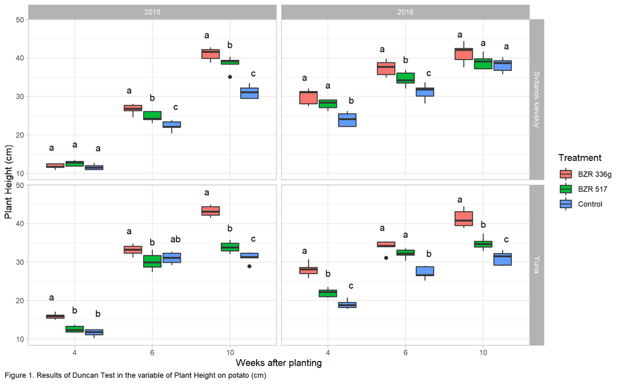

```r
library(agricolae)
library(ggplot2)
library(ggpubr)
#Plant Height Duncan Graph

ggplot(Data.Cultivars.Final, aes(x=`Weeks after planting`, y=Plant.Height, fill=Treatment))+ylab("Plant Height (cm)")+
  geom_boxplot()+
  facet_grid(Cultivar~Year)+
  theme_light()+
  geom_text(data = LettersPH,
            mapping = aes(x = Weeks.after.planting,
                          y = mea + 5,
                          label = letra),
            position = position_dodge(0.9))+
  labs(caption = "Figure 1. Results of Duncan Test in the variable of Plant Height on potato (cm)") +
  theme(plot.caption.position = "plot",
        plot.caption = element_text(hjust = 0))
```

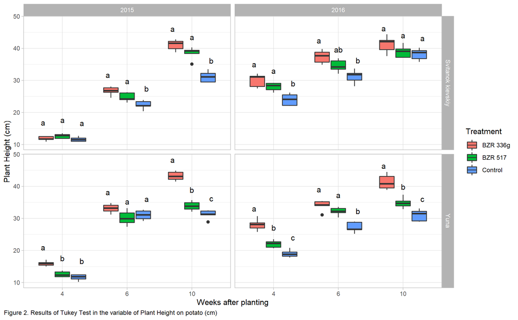

```r
#Plant Height Tukey Graph

ggplot(Data.Cultivars.Final, aes(x=`Weeks after planting`, y=Plant.Height, fill=Treatment))+ylab("Plant Height (cm)")+
  geom_boxplot()+
  facet_grid(Cultivar~Year)+
  theme_light()+
  geom_text(data = LettersPHz,
            mapping = aes(x = Weeks.after.planting,
                          y = mea + 5,
                          label = letra),
            position = position_dodge(0.9))+
  labs(caption = "Figure 2. Results of Tukey Test in the variable of Plant Height on potato (cm)") +
  theme(plot.caption.position = "plot",
        plot.caption = element_text(hjust = 0))
```

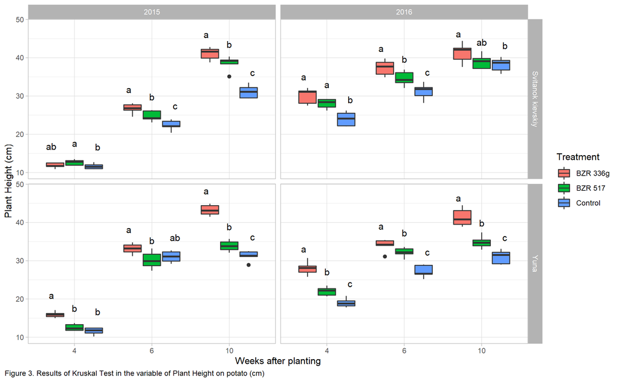

```r
ggplot(Data.Cultivars.Final, aes(x=`Weeks after planting`, y=Plant.Height, fill=Treatment))+ylab("Plant Height (cm)")+
  geom_boxplot()+
  facet_grid(Cultivar~Year)+
  theme_light()+
  geom_text(data = LettersPHk,
            mapping = aes(x = Weeks.after.planting,
                          y = mea + 5,
                          label = letra),
            position = position_dodge(0.9))+
  labs(caption = "Figure 3. Results of Kruskal Test in the variable of Plant Height on potato (cm)") +
  theme(plot.caption.position = "plot",
        plot.caption = element_text(hjust = 0))
```

```r
#Residuals Plant Height
anova.ph<-aov(Plant.Height~Treatment+`Weeks after planting`+Year, data=Data.Cultivars.Final) #anova
anova.ph.sqrt <- aov(sqrt(Plant.Height)~Treatment+`Weeks after planting`+Year, data=Data.Cultivars.Final) #square root
shapiro.test(anova.ph$residuals) #0.0329 anormal
```

```
##
##  Shapiro-Wilk normality test
##
## data:  anova.ph$residuals
## W = 0.9836, p-value = 0.03299
```

```r
shapiro.test(anova.ph.sqrt$residuals) #0.02933
```

```
##
##  Shapiro-Wilk normality test
##
## data:  anova.ph.sqrt$residuals
## W = 0.98322, p-value = 0.02933
```

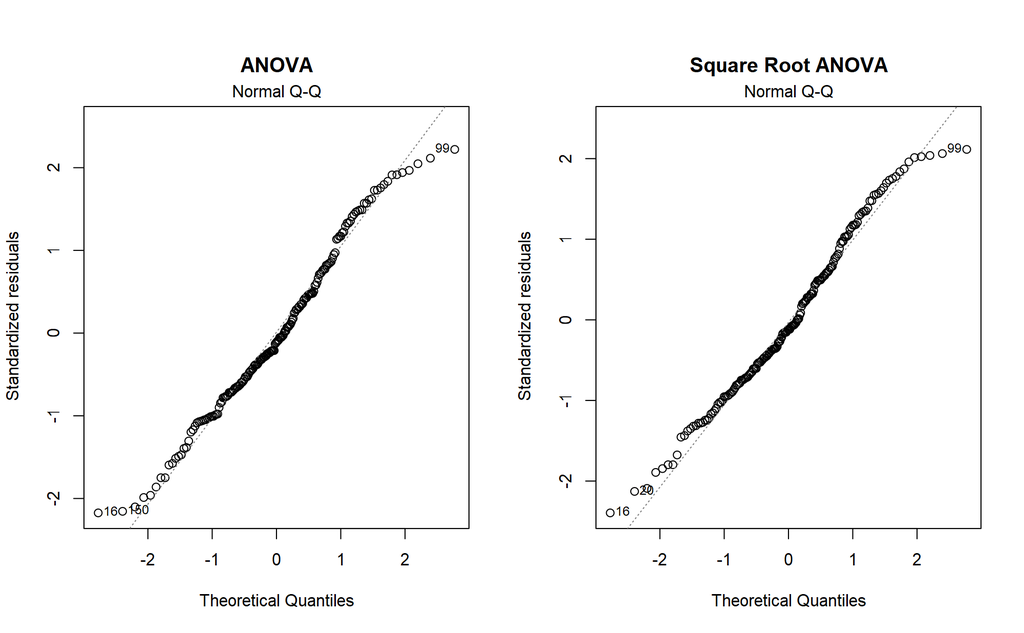

```r
par(mfrow = c(1, 2), oma = c(0, 0, 1.1, 0))
plot(anova.ph, main = "ANOVA", which = 2, ask = F,sub.caption = "")
plot(anova.ph.sqrt, main = "Square Root ANOVA", which = 2, ask = F,sub.caption = "")
```

Figure 4. Normality of Residuals Plant Height

```r
#AIC and BIC Plant Height
AIC(anova.ph, anova.ph.sqrt)
```

```
##               df       AIC
## anova.ph       7 1001.9581
## anova.ph.sqrt  7  187.3949
```

```r
BIC(anova.ph, anova.ph.sqrt)
```

```
##               df       BIC
## anova.ph       7 1024.3088
## anova.ph.sqrt  7  209.7456
```

**1.2 Disease Incidence**

```r
#Disease Incidence
#Anova Disease Incidence
model<-aov(Disease.Incidence~Treatment+`Weeks after planting`+Year, data=Data.Cultivars.Final)
summary(model)
Data.Cultivars.Final$`Weeks after planting` <- factor(Data.Cultivars.Final$`Weeks after planting`)


#Duncan Test Disease Incidence

Y <- W <- Tr <- L <- C <- M <- numeric()

for (i in 2015:2016) {
  for (k in levels(as.factor(Data.Cultivars.Final$Cultivar))) {
    for(j in levels(Data.Cultivars.Final$`Weeks after planting`)) {
      d1 <- Data.Cultivars.Final[Data.Cultivars.Final$Year==i &
                                   Data.Cultivars.Final$`Weeks after planting`==j &
                                   Data.Cultivars.Final$Cultivar==k, ]
      model <- aov(Disease.Incidence~Treatment, data=d1)
      summary(model)
      DT <- duncan.test(model, "Treatment", console = TRUE)
      Y <- c(Y, i,i,i)
      W <- c(W, j,j,j)
      C <- c(C, k,k,k)
      Tr <- c(Tr, row.names(DT$groups))
      L <- c(L, DT$groups$groups)
      M <- c(M, DT$groups$Disease.Incidence)
    }
  }
}


LettersDI <- data.frame(Year = Y, `Weeks after planting` = factor(W),
                        Cultivar = C, Treatment = factor(Tr), letra = L, mea = M)

#Tukey Disease Incidence

Y <- W <- Tr <- L <- C <- M <- numeric()

for (i in 2015:2016) {
  for (k in levels(as.factor(Data.Cultivars.Final$Cultivar))) {
    for(j in levels(Data.Cultivars.Final$`Weeks after planting`)) {
      d1z <- Data.Cultivars.Final[Data.Cultivars.Final$Year==i &
                                    Data.Cultivars.Final$`Weeks after planting`==j &
                                    Data.Cultivars.Final$Cultivar==k, ]
      model <- aov(Disease.Incidence~Treatment, data=d1z)
      summary(model)
      DT <- HSD.test(model, "Treatment", console = TRUE)
      Y <- c(Y, i,i,i)
      W <- c(W, j,j,j)
      C <- c(C, k,k,k)
      Tr <- c(Tr, row.names(DT$groups))
      L <- c(L, DT$groups$groups)
      M <- c(M, DT$groups$Disease.Incidence)
    }
  }
}


LettersDIz <- data.frame(Year = Y, `Weeks after planting` = factor(W),
                         Cultivar = C, Treatment = factor(Tr), letra = L, mea = M)

#Disease Incidence Kruskal

Y <- W <- Tr <- L <- C <- M <- numeric()

for (i in 2015:2016) {
  for (k in levels(as.factor(Data.Cultivars.Final$Cultivar))) {
    for(j in levels(Data.Cultivars.Final$`Weeks after planting`)) {
      d1k <- Data.Cultivars.Final[Data.Cultivars.Final$Year==i &
                                    Data.Cultivars.Final$`Weeks after planting`==j &
                                    Data.Cultivars.Final$Cultivar==k, ]
      d1k$Treatment <- factor(d1k$Treatment)
      kw <- with(d1k,kruskal(Disease.Incidence,Treatment))
      gr <- kw$groups
      lt <- gr$groups[order(row.names(gr))]
      Y <- c(Y, i,i,i)
      W <- c(W, j,j,j)
      C <- c(C, k,k,k)
      Tr <- c(Tr, levels(d1k$Treatment))
      L <- c(L, lt)
      M <- c(M, mean(d1k$Disease.Incidence[d1k$Treatment == levels(d1k$Treatment)[1]]),
             mean(d1k$Disease.Incidence[d1k$Treatment == levels(d1k$Treatment)[2]]),
             mean(d1k$Disease.Incidence[d1k$Treatment == levels(d1k$Treatment)[3]]))
    }
  }
}

LettersDIk <- data.frame(Year = Y, `Weeks after planting` = factor(W),
                         Cultivar = C, Treatment = factor(Tr), letra = L, mea = M)
```

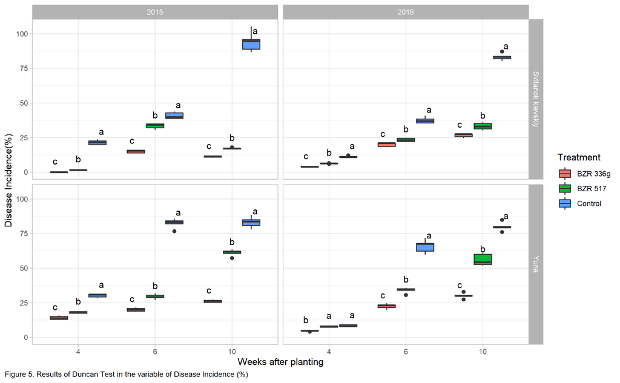

```r
#Duncan Graph Disease Incidence
ggplot(Data.Cultivars.Final, aes(x=`Weeks after planting`, y=Disease.Incidence, fill=Treatment))+ylab("Disease Incidence(%)")+
  geom_boxplot()+
  facet_grid(Cultivar~Year)+
  theme_light()+
  geom_text(data = LettersDI,
            mapping = aes(x = Weeks.after.planting,
                          y = mea + 8,
                          label = letra),
            position = position_dodge(0.9))+
  labs(caption = "Figure 5. Results of Duncan Test in the variable of Disease Incidence (%)") +
  theme(plot.caption.position = "plot",
        plot.caption = element_text(hjust = 0))
```

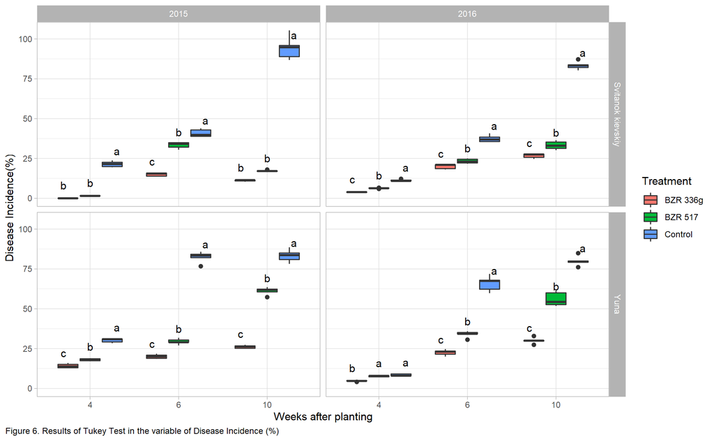

```r
#Tukey Graph Disease Incidence
library(ggplot2)
ggplot(Data.Cultivars.Final, aes(x=`Weeks after planting`, y=Disease.Incidence, fill=Treatment))+ylab("Disease Incidence(%)")+
  geom_boxplot()+
  facet_grid(Cultivar~Year)+
  theme_light()+
  geom_text(data = LettersDIz,
            mapping = aes(x = Weeks.after.planting,
                          y = mea + 8,
                          label = letra),
            position = position_dodge(0.9))+
  labs(caption = "Figure 6. Results of Tukey Test in the variable of Disease Incidence (%)") +
  theme(plot.caption.position = "plot",
        plot.caption = element_text(hjust = 0))
```

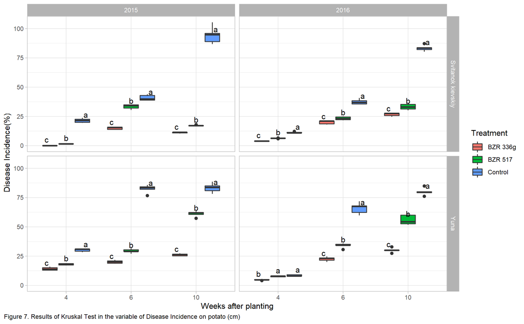

```r
#Disease Incidence Kruskal Graph

ggplot(Data.Cultivars.Final, aes(x=`Weeks after planting`, y=Disease.Incidence, fill=Treatment))+ylab("Disease Incidence(%)")+
  geom_boxplot()+
  facet_grid(Cultivar~Year)+
  theme_light()+
  geom_text(data = LettersDIk,
            mapping = aes(x = Weeks.after.planting,
                          y = mea + 5,
                          label = letra),
            position = position_dodge(0.9))+
  labs(caption = "Figure 7. Results of Kruskal Test in the variable of Disease Incidence on potato (cm)") +
  theme(plot.caption.position = "plot",
        plot.caption = element_text(hjust = 0))
```

```r
#Residuals Disease Incidence
anova.di<-aov(Disease.Incidence~Treatment+`Weeks after planting`+Year, data=Data.Cultivars.Final) #anova
anova.di.sqrt <- aov(sqrt(Disease.Incidence)~Treatment+`Weeks after planting`+Year, data=Data.Cultivars.Final) #square root
shapiro.test(anova.di$residuals) #0.03132 anormal
```

```
##
##  Shapiro-Wilk normality test
##
## data:  anova.di$residuals
## W = 0.98343, p-value = 0.03132
```

```r
shapiro.test(anova.di.sqrt$residuals) #0.001165
```

```
##
##  Shapiro-Wilk normality test
##
## data:  anova.di.sqrt$residuals
## W = 0.97222, p-value = 0.001165
```

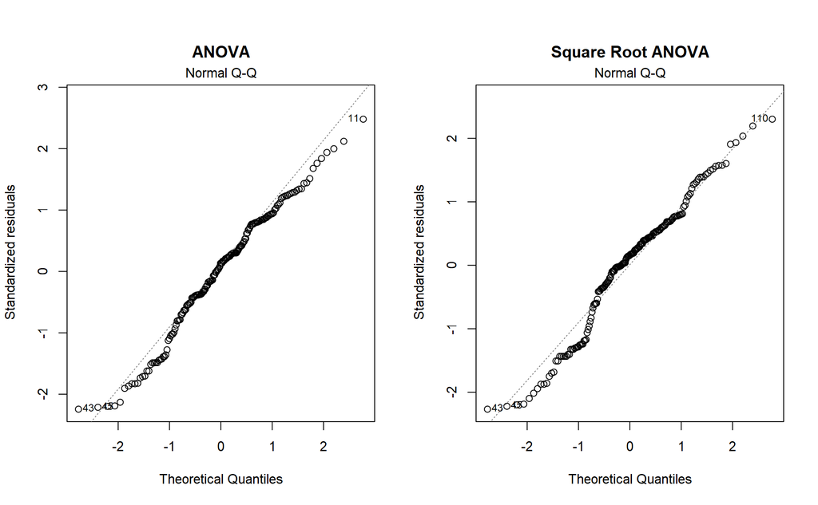

```r
par(mfrow = c(1, 2), oma = c(0, 0, 1.1, 0))
plot(anova.di, main = "ANOVA", which = 2, ask = F,sub.caption = "")
plot(anova.di.sqrt, main = "Square Root ANOVA", which = 2, ask = F,sub.caption = "")
```

Figure 8. Normality of Residuals Disease Incidence

```r
#AIC and BIC Disease Incidence
AIC(anova.di, anova.di.sqrt)
```

```
##               df       AIC
## anova.di       7 1454.2804
## anova.di.sqrt  7  549.3612
```

```r
BIC(anova.di, anova.di.sqrt)
```

```
##               df       BIC
## anova.di       7 1476.6311
## anova.di.sqrt  7  571.7119
```

**1.3 Disease Severity**

Taking into account the Kruskal test for disease severity, we can see a big difference between the control and the treatments principally 10 weeks after planting. In all cases, at this time, the first treatment (BZR 336g) generates the lower disease severity and the second (BZR 517) is an intermediate value, when compared to the control.

```r
#Disease Severity

#Anova Disease Severity
model<-aov(Disease.Severity~Treatment+`Weeks after planting`+Year, data=Data.Cultivars.Final)
summary(model)
Data.Cultivars.Final$`Weeks after planting` <- factor(Data.Cultivars.Final$`Weeks after planting`)
#Disease Severity Duncan Test

Y <- W <- Tr <- L <- C <- M <- numeric()

for (i in 2015:2016) {
  for (k in levels(as.factor(Data.Cultivars.Final$Cultivar))) {
    for(j in levels(Data.Cultivars.Final$`Weeks after planting`)) {
      d1 <- Data.Cultivars.Final[Data.Cultivars.Final$Year==i &
                                   Data.Cultivars.Final$`Weeks after planting`==j &
                                   Data.Cultivars.Final$Cultivar==k, ]
      model <- aov(Disease.Severity~Treatment, data=d1)
      summary(model)
      DT <- duncan.test(model, "Treatment", console = TRUE)
      Y <- c(Y, i,i,i)
      W <- c(W, j,j,j)
      C <- c(C, k,k,k)
      Tr <- c(Tr, row.names(DT$groups))
      L <- c(L, DT$groups$groups)
      M <- c(M, DT$groups$Disease.Severity)
    }
  }
}


LettersDS <- data.frame(Year = Y, `Weeks after planting` = factor(W),
                        Cultivar = C, Treatment = factor(Tr), letra = L, mea = M)

#Tukey Test Disease Severity

Y <- W <- Tr <- L <- C <- M <- numeric()

for (i in 2015:2016) {
  for (k in levels(as.factor(Data.Cultivars.Final$Cultivar))) {
    for(j in levels(Data.Cultivars.Final$`Weeks after planting`)) {
      d1z <- Data.Cultivars.Final[Data.Cultivars.Final$Year==i &
                                    Data.Cultivars.Final$`Weeks after planting`==j &
                                    Data.Cultivars.Final$Cultivar==k, ]
      model <- aov(Disease.Severity~Treatment, data=d1z)
      summary(model)
      DT <- HSD.test(model, "Treatment", console = TRUE)
      Y <- c(Y, i,i,i)
      W <- c(W, j,j,j)
      C <- c(C, k,k,k)
      Tr <- c(Tr, row.names(DT$groups))
      L <- c(L, DT$groups$groups)
      M <- c(M, DT$groups$Disease.Severity)
    }
  }
}


LettersDSz <- data.frame(Year = Y, `Weeks after planting` = factor(W),
                         Cultivar = C, Treatment = factor(Tr), letra = L, mea = M)

#Disease Severity Kruskal

Y <- W <- Tr <- L <- C <- M <- numeric()

for (i in 2015:2016) {
  for (k in levels(as.factor(Data.Cultivars.Final$Cultivar))) {
    for(j in levels(Data.Cultivars.Final$`Weeks after planting`)) {
      d1k <- Data.Cultivars.Final[Data.Cultivars.Final$Year==i &
                                    Data.Cultivars.Final$`Weeks after planting`==j &
                                    Data.Cultivars.Final$Cultivar==k, ]
      d1k$Treatment <- factor(d1k$Treatment)
      kw <- with(d1k,kruskal(Disease.Severity,Treatment))
      gr <- kw$groups
      lt <- gr$groups[order(row.names(gr))]
      Y <- c(Y, i,i,i)
      W <- c(W, j,j,j)
      C <- c(C, k,k,k)
      Tr <- c(Tr, levels(d1k$Treatment))
      L <- c(L, lt)
      M <- c(M, mean(d1k$Disease.Severity[d1k$Treatment == levels(d1k$Treatment)[1]]),
             mean(d1k$Disease.Severity[d1k$Treatment == levels(d1k$Treatment)[2]]),
             mean(d1k$Disease.Severity[d1k$Treatment == levels(d1k$Treatment)[3]]))
    }
  }
}

LettersDSk <- data.frame(Year = Y, `Weeks after planting` = factor(W),
                         Cultivar = C, Treatment = factor(Tr), letra = L, mea = M)
```

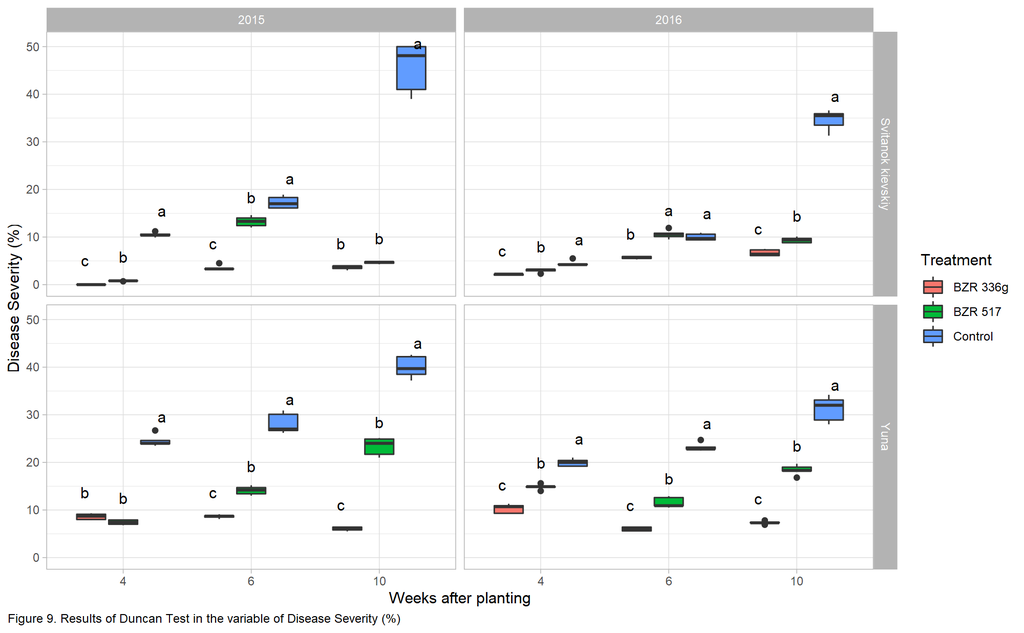

```r
#Duncan Graph Disease Severity
ggplot(Data.Cultivars.Final, aes(x=`Weeks after planting`, y=Disease.Severity, fill=Treatment))+ylab("Disease Severity (%)")+
  geom_boxplot()+
  facet_grid(Cultivar~Year)+
  theme_light()+
  geom_text(data = LettersDS,
            mapping = aes(x = Weeks.after.planting,
                          y = mea + 5,
                          label = letra),
            position = position_dodge(0.9))+
  labs(caption = "Figure 9. Results of Duncan Test in the variable of Disease Severity (%)") +
  theme(plot.caption.position = "plot",
        plot.caption = element_text(hjust = 0))
```

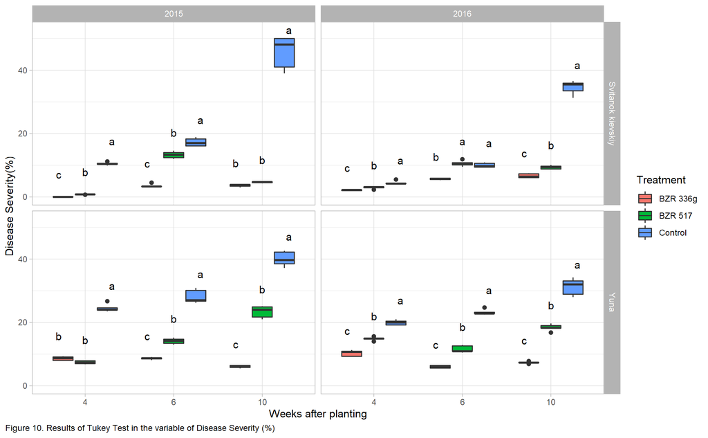

```r
#Tukey Graph Disease Severity

ggplot(Data.Cultivars.Final, aes(x=`Weeks after planting`, y=Disease.Severity, fill=Treatment))+ylab("Disease Severity(%)")+
  geom_boxplot()+
  facet_grid(Cultivar~Year)+
  theme_light()+
  geom_text(data = LettersDSz,
            mapping = aes(x = Weeks.after.planting,
                          y = mea + 7,
                          label = letra),
            position = position_dodge(0.9))+
  labs(caption = "Figure 10. Results of Tukey Test in the variable of Disease Severity (%)") +
  theme(plot.caption.position = "plot",
        plot.caption = element_text(hjust = 0))
```

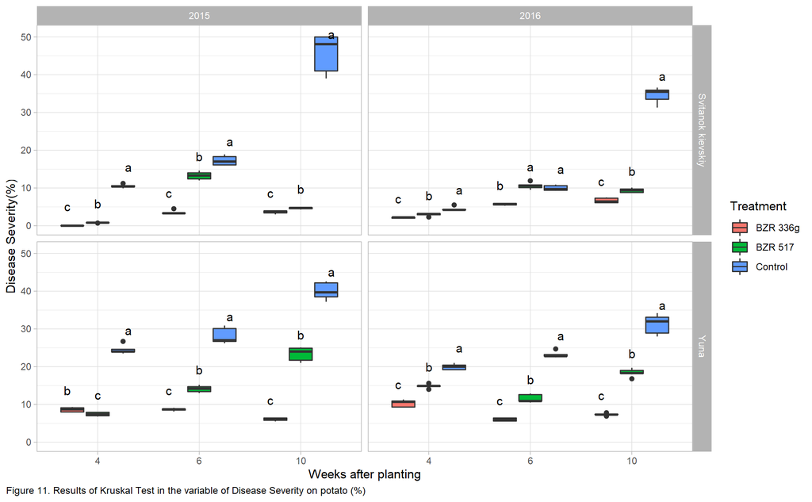

```r
#Disease Severity Kruskal Graph

ggplot(Data.Cultivars.Final, aes(x=`Weeks after planting`, y=Disease.Severity, fill=Treatment))+ylab("Disease Severity(%)")+
  geom_boxplot()+
  facet_grid(Cultivar~Year)+
  theme_light()+
  geom_text(data = LettersDSk,
            mapping = aes(x = Weeks.after.planting,
                          y = mea + 5,
                          label = letra),
            position = position_dodge(0.9))+
  labs(caption = "Figure 11. Results of Kruskal Test in the variable of Disease Severity on potato (%)") +
  theme(plot.caption.position = "plot",
        plot.caption = element_text(hjust = 0))
```

```r
#Residuals Disease Severity
anova.ds<-aov(Disease.Severity~Treatment+`Weeks after planting`+Year, data=Data.Cultivars.Final) #anova
anova.ds.sqrt <- aov(sqrt(Disease.Severity)~Treatment+`Weeks after planting`+Year, data=Data.Cultivars.Final) #square root
shapiro.test(anova.ds$residuals) #0.002356 anormal
```

```
##
##  Shapiro-Wilk normality test
##
## data:  anova.ds$residuals
## W = 0.97475, p-value = 0.002356
```

```r
shapiro.test(anova.ds.sqrt$residuals) #0.0009698
```

```
##
##  Shapiro-Wilk normality test
##
## data:  anova.ds.sqrt$residuals
## W = 0.97155, p-value = 0.0009698
```

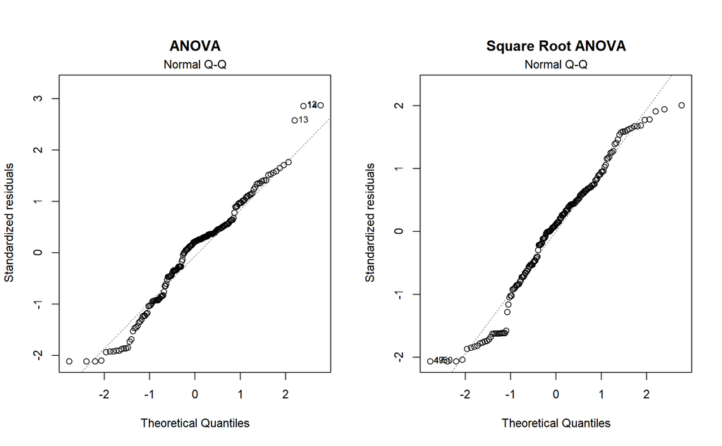

```r
par(mfrow = c(1, 2), oma = c(0, 0, 1.1, 0))
plot(anova.ds, main = "ANOVA", which = 2, ask = F,sub.caption = "")
plot(anova.ds.sqrt, main = "Square Root ANOVA", which = 2, ask = F,sub.caption = "")
```

Figure 12. Normality of Residuals Disease Severity

```r
#AIC and BIC Disease Severity
AIC(anova.ds, anova.ds.sqrt)
```

```
##               df      AIC
## anova.ds       7 1213.955
## anova.ds.sqrt  7  500.044
```

```r
BIC(anova.ds, anova.ds.sqrt)
```

```
##               df       BIC
## anova.ds       7 1236.3059
## anova.ds.sqrt  7  522.3947
```

**1.4 Number of stems**

```r
#Stems
#Anova Stems
model<-aov(Stems~Treatment+`Weeks after planting`+Year, data=Data.Cultivars.Final)
summary(model)
Data.Cultivars.Final$`Weeks after planting` <- factor(Data.Cultivars.Final$`Weeks after planting`)

#Duncant Test Stems
Y <- W <- Tr <- L <- C <- M <- numeric()

for (i in 2015:2016) {
  for (k in levels(as.factor(Data.Cultivars.Final$Cultivar))) {
    for(j in levels(Data.Cultivars.Final$`Weeks after planting`)) {
      d1 <- Data.Cultivars.Final[Data.Cultivars.Final$Year==i &
                                   Data.Cultivars.Final$`Weeks after planting`==j &
                                   Data.Cultivars.Final$Cultivar==k, ]
      model <- aov(Stems~Treatment, data=d1)
      summary(model)
      DT <- duncan.test(model, "Treatment", console = TRUE)
      Y <- c(Y, i,i,i)
      W <- c(W, j,j,j)
      C <- c(C, k,k,k)
      Tr <- c(Tr, row.names(DT$groups))
      L <- c(L, DT$groups$groups)
      M <- c(M, DT$groups$Stems)
    }
  }
}


LettersST <- data.frame(Year = Y, `Weeks after planting` = factor(W),
                        Cultivar = C, Treatment = factor(Tr), letra = L, mea = M)

#Tukey Graph Stems

Y <- W <- Tr <- L <- C <- M <- numeric()

for (i in 2015:2016) {
  for (k in levels(as.factor(Data.Cultivars.Final$Cultivar))) {
    for(j in levels(Data.Cultivars.Final$`Weeks after planting`)) {
      d1z <- Data.Cultivars.Final[Data.Cultivars.Final$Year==i &
                                    Data.Cultivars.Final$`Weeks after planting`==j &
                                    Data.Cultivars.Final$Cultivar==k, ]
      model <- aov(Stems~Treatment, data=d1z)
      summary(model)
      DT <- HSD.test(model, "Treatment", console = TRUE)
      Y <- c(Y, i,i,i)
      W <- c(W, j,j,j)
      C <- c(C, k,k,k)
      Tr <- c(Tr, row.names(DT$groups))
      L <- c(L, DT$groups$groups)
      M <- c(M, DT$groups$Stems)
    }
  }
}


LettersSTz <- data.frame(Year = Y, `Weeks after planting` = factor(W),
                         Cultivar = C, Treatment = factor(Tr), letra = L, mea = M)

#Stems Kruskal

Y <- W <- Tr <- L <- C <- M <- numeric()

for (i in 2015:2016) {
  for (k in levels(as.factor(Data.Cultivars.Final$Cultivar))) {
    for(j in levels(Data.Cultivars.Final$`Weeks after planting`)) {
      d1k <- Data.Cultivars.Final[Data.Cultivars.Final$Year==i &
                                    Data.Cultivars.Final$`Weeks after planting`==j &
                                    Data.Cultivars.Final$Cultivar==k, ]
      d1k$Treatment <- factor(d1k$Treatment)
      kw <- with(d1k,kruskal(Stems,Treatment))
      gr <- kw$groups
      lt <- gr$groups[order(row.names(gr))]
      Y <- c(Y, i,i,i)
      W <- c(W, j,j,j)
      C <- c(C, k,k,k)
      Tr <- c(Tr, levels(d1k$Treatment))
      L <- c(L, lt)
      M <- c(M, mean(d1k$Stems[d1k$Treatment == levels(d1k$Treatment)[1]]),
             mean(d1k$Stems[d1k$Treatment == levels(d1k$Treatment)[2]]),
             mean(d1k$Stems[d1k$Treatment == levels(d1k$Treatment)[3]]))
    }
  }
}

LettersSTk <- data.frame(Year = Y, `Weeks after planting` = factor(W),
                         Cultivar = C, Treatment = factor(Tr), letra = L, mea = M)
```

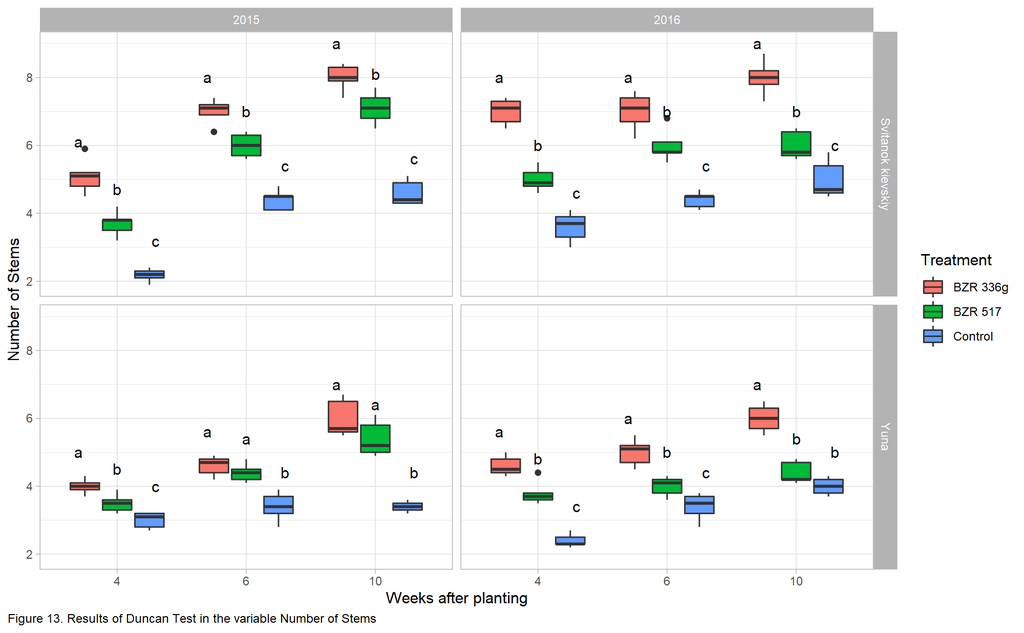

```r
#Duncan Graph Stems
ggplot(Data.Cultivars.Final, aes(x=`Weeks after planting`, y=Stems, fill=Treatment))+ylab("Number of Stems")+
  geom_boxplot()+
  facet_grid(Cultivar~Year)+
  theme_light()+
  geom_text(data = LettersST,
            mapping = aes(x = Weeks.after.planting,
                          y = mea + 1,
                          label = letra),
            position = position_dodge(0.9))+
  labs(caption = "Figure 13. Results of Duncan Test in the variable Number of Stems") +
  theme(plot.caption.position = "plot",
        plot.caption = element_text(hjust = 0))
```

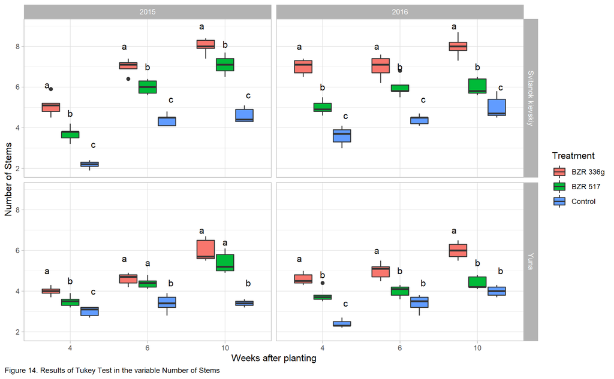

```r
#Tukey Graph Stems
ggplot(Data.Cultivars.Final, aes(x=`Weeks after planting`, y=Stems, fill=Treatment))+ylab("Number of Stems")+
  geom_boxplot()+
  facet_grid(Cultivar~Year)+
  theme_light()+
  geom_text(data = LettersSTz,
            mapping = aes(x = Weeks.after.planting,
                          y = mea + 1,
                          label = letra),
            position = position_dodge(0.9))+
  labs(caption = "Figure 14. Results of Tukey Test in the variable Number of Stems") +
  theme(plot.caption.position = "plot",
        plot.caption = element_text(hjust = 0))
```

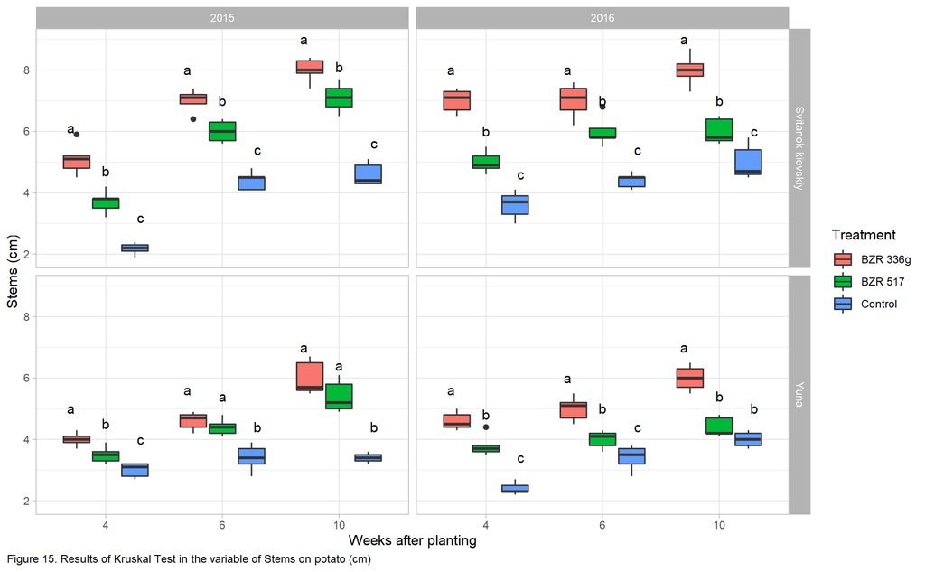

```r
#Stems Kruskal Graph

ggplot(Data.Cultivars.Final, aes(x=`Weeks after planting`, y=Stems, fill=Treatment))+ylab("Stems (cm)")+
  geom_boxplot()+
  facet_grid(Cultivar~Year)+
  theme_light()+
  geom_text(data = LettersSTk,
            mapping = aes(x = Weeks.after.planting,
                          y = mea + 1,
                          label = letra),
            position = position_dodge(0.9))+
  labs(caption = "Figure 15. Results of Kruskal Test in the variable of Stems on potato (cm)") +
  theme(plot.caption.position = "plot",
        plot.caption = element_text(hjust = 0))
```

```r
#Residuals Stems
anova.st<-aov(Stems~Treatment+`Weeks after planting`+Year, data=Data.Cultivars.Final) #anova
anova.st.sqrt <- aov(sqrt(Stems)~Treatment+`Weeks after planting`+Year, data=Data.Cultivars.Final) #square root
shapiro.test(anova.st$residuals) #0.007876 anormal
```

```
##
##  Shapiro-Wilk normality test
##
## data:  anova.st$residuals
## W = 0.9789, p-value = 0.007876
```

```r
shapiro.test(anova.st.sqrt$residuals) #0.002167
```

```
##
##  Shapiro-Wilk normality test
##
## data:  anova.st.sqrt$residuals
## W = 0.97445, p-value = 0.002167
```

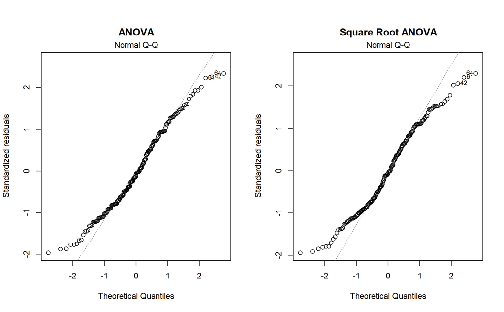

```r
par(mfrow = c(1, 2), oma = c(0, 0, 1.1, 0))
plot(anova.st, main = "ANOVA", which = 2, ask = F,sub.caption = "")
plot(anova.st.sqrt, main = "Square Root ANOVA", which = 2, ask = F,sub.caption = "")
```

Figure 16. Normality of Residuals Stems

```r
#AIC and BIC Stems
AIC(anova.st, anova.st.sqrt)
```

```
##               df       AIC
## anova.st       7 495.88079
## anova.st.sqrt  7 -50.13636
```

```r
BIC(anova.st, anova.st.sqrt)
```

```
##               df       BIC
## anova.st       7 518.23149
## anova.st.sqrt  7 -27.78566
```

**2) Effect of *B. velezens* strains on the biomass distribution of daughter tubers of two potato cultivars differed by disease resistance to *R. solani* and total yield during 2015 and 2016 growing seasons in Western Siberia.**

**2.1 Biomass distribution**

We can’t see differences between the results of Duncan, Tukey and Kruskal test, in the differences between treatments (Figures 17, 18 and 19). The Shapiro-Wilk normality test was performed for Anova and Square Root Anova because in Anova p was higher than 0.05, what means that the data follow a normal distribution (Figure 20) and, in this case, the best test to be used is the Tukey test, to compare the differences between the treatments.

Taking into account the Tukey test for the biomass distribution, we can see that we have more biomass in the medium fraction and also that the efficiency of the treatments changes depending on the fraction. In this way we can see that, for the large fraction, the treatment BZR 336g results in the higher biomass production, however when we analyze the small fractions, the higher production of biomass takes place in the control. For the medium fractions, the treatment BZR 517 proved to be the most effective, however, there was no significant difference between the control for the cultivar Yuna.

```r
#Prueba Biomass
model<-aov(Percentage.Biomass~Treatment+`Fractions`+Year, data=BiomassDistribution)
summary(model)
BiomassDistribution$`Fractions` <- factor(BiomassDistribution$`Fractions`)

#Biomass Duncant Test
Y <- W <- Tr <- L <- C <- M <- numeric()

for (i in 2015:2016) {
  for (k in levels(as.factor(BiomassDistribution$Cultivar))) {
    for(j in levels(BiomassDistribution$`Fractions`)) {
      d200 <- BiomassDistribution[BiomassDistribution$Year==i &
                                   BiomassDistribution$`Fractions`==j &
                                   BiomassDistribution$Cultivar==k, ]
      model <- aov(Percentage.Biomass~Treatment, data=d200)
      summary(model)
      DT <- duncan.test(model, "Treatment", console = TRUE)
      Y <- c(Y, i,i,i)
      W <- c(W, j,j,j)
      C <- c(C, k,k,k)
      Tr <- c(Tr, row.names(DT$groups))
      L <- c(L, DT$groups$groups)
      M <- c(M, DT$groups$Percentage.Biomass)
    }
  }
}

LettersPH1 <- data.frame(Year = Y, `Fractions` = factor(W),
                         Cultivar = C, Treatment = factor(Tr), letra = L, mea = M)



#Prueba Biomass tukey
library(agricolae)
Y <- W <- Tr <- L <- C <- M <- numeric()

for (i in 2015:2016) {
  for (k in levels(as.factor(BiomassDistribution$Cultivar))) {
    for(j in levels(BiomassDistribution$`Fractions`)) {
      t200 <- BiomassDistribution[BiomassDistribution$Year==i &
                                    BiomassDistribution$`Fractions`==j &
                                    BiomassDistribution$Cultivar==k, ]
      model <- aov(Percentage.Biomass~Treatment, data=t200)
      summary(model)
      DT <- HSD.test(model, "Treatment", console = TRUE)
      Y <- c(Y, i,i,i)
      W <- c(W, j,j,j)
      C <- c(C, k,k,k)
      Tr <- c(Tr, row.names(DT$groups))
      L <- c(L, DT$groups$groups)
      M <- c(M, DT$groups$Percentage.Biomass)
    }
  }
}
LetterstPH11 <- data.frame(Year = Y, `Fractions` = factor(W),
                           Cultivar = C, Treatment = factor(Tr), letra = L, mea = M)

#Biomass Kruskal

Y <- W <- Tr <- L <- C <- M <- numeric()

for (i in 2015:2016) {
  for (k in levels(as.factor(BiomassDistribution$Cultivar))) {
    for(j in levels(BiomassDistribution$`Fractions`)) {
      d1k <- BiomassDistribution[BiomassDistribution$Year==i &
                                   BiomassDistribution$`Fractions`==j &
                                   BiomassDistribution$Cultivar==k, ]
      d1k$Treatment <- factor(d1k$Treatment)
      kw <- with(d1k,kruskal(Percentage.Biomass,Treatment))
      gr <- kw$groups
      lt <- gr$groups[order(row.names(gr))]
      Y <- c(Y, i,i,i)
      W <- c(W, j,j,j)
      C <- c(C, k,k,k)
      Tr <- c(Tr, levels(d1k$Treatment))
      L <- c(L, lt)
      M <- c(M, mean(d1k$Percentage.Biomass[d1k$Treatment == levels(d1k$Treatment)[1]]),
             mean(d1k$Percentage.Biomass[d1k$Treatment == levels(d1k$Treatment)[2]]),
             mean(d1k$Percentage.Biomass[d1k$Treatment == levels(d1k$Treatment)[3]]))
    }
  }
}

LettersPH12 <- data.frame(Year = Y, `Fractions` = factor(W),
                         Cultivar = C, Treatment = factor(Tr), letra = L, mea = M)
```

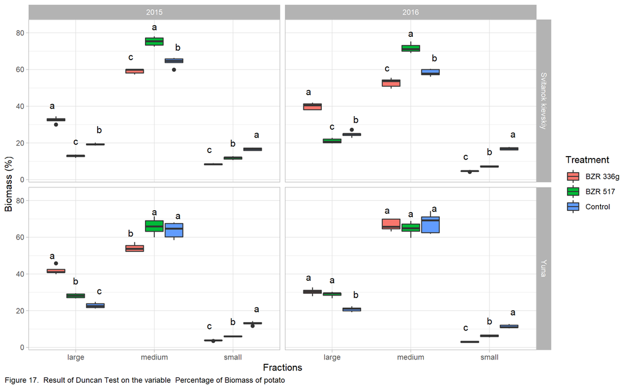

```r
#Biomass Graph Duncan
ggplot(BiomassDistribution, aes(x=`Fractions`, y=Percentage.Biomass, fill=Treatment))+ylab("Biomass (%)")+
  geom_boxplot()+
  facet_grid(Cultivar~Year)+
  theme_light()+
  geom_text(data = LettersPH1,
            mapping = aes(x = Fractions,
                          y = mea + 8,
                          label = letra),
            position = position_dodge(0.9))+
  labs(caption = "Figure 17.  Result of Duncan Test on the variable  Percentage of Biomass of potato") +
  theme(plot.caption.position = "plot",
        plot.caption = element_text(hjust = 0))
```

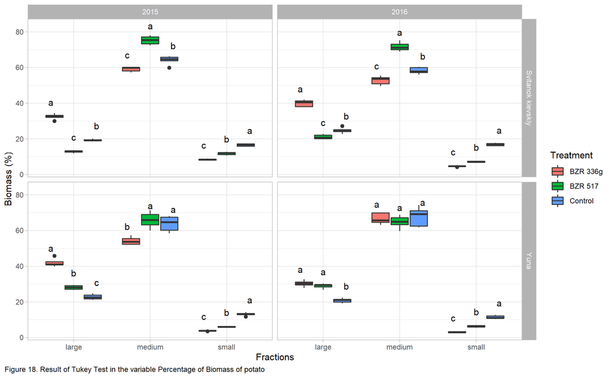

```r
#Biomass Graph Tukey
ggplot(BiomassDistribution, aes(x=`Fractions`, y=Percentage.Biomass, fill=Treatment))+ ylab("Biomass (%)")+
  geom_boxplot()+
  facet_grid(Cultivar~Year)+
  theme_light()+
  geom_text(data = LetterstPH11,
            mapping = aes(x = Fractions,
                          y = mea + 8,
                          label = letra),
            position = position_dodge(0.9))+
  labs(caption = "Figure 18. Result of Tukey Test in the variable Percentage of Biomass of potato") +
  theme(plot.caption.position = "plot",
        plot.caption = element_text(hjust = 0))
```

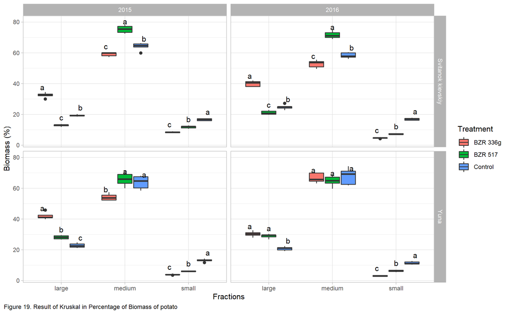

```r
#Biomass Kruskal Graph

ggplot(BiomassDistribution, aes(x=`Fractions`, y=Percentage.Biomass, fill=Treatment))+ylab("Biomass (%)")+
  geom_boxplot()+
  facet_grid(Cultivar~Year)+
  theme_light()+
  geom_text(data = LettersPH12,
            mapping = aes(x = Fractions,
                          y = mea + 5,
                          label = letra),
            position = position_dodge(0.9))+
  labs(caption = "Figure 19. Result of Kruskal in Percentage of Biomass of potato") +
  theme(plot.caption.position = "plot",
        plot.caption = element_text(hjust = 0))
```

```r
#Residuals Biomass
anova.biomass<-aov(Percentage.Biomass~Treatment+`Fractions`+Year, data=BiomassDistribution) #anova
anova.biomass.sqrt <- aov(sqrt(Percentage.Biomass)~Treatment+`Fractions`+Year, data=BiomassDistribution) #square root
shapiro.test(anova.biomass$residuals) #0.06424
```

```
##
##  Shapiro-Wilk normality test
##
## data:  anova.biomass$residuals
## W = 0.98573, p-value = 0.06424
```

```r
shapiro.test(anova.biomass.sqrt$residuals) #0.3364
```

```
##
##  Shapiro-Wilk normality test
##
## data:  anova.biomass.sqrt$residuals
## W = 0.99117, p-value = 0.3364
```

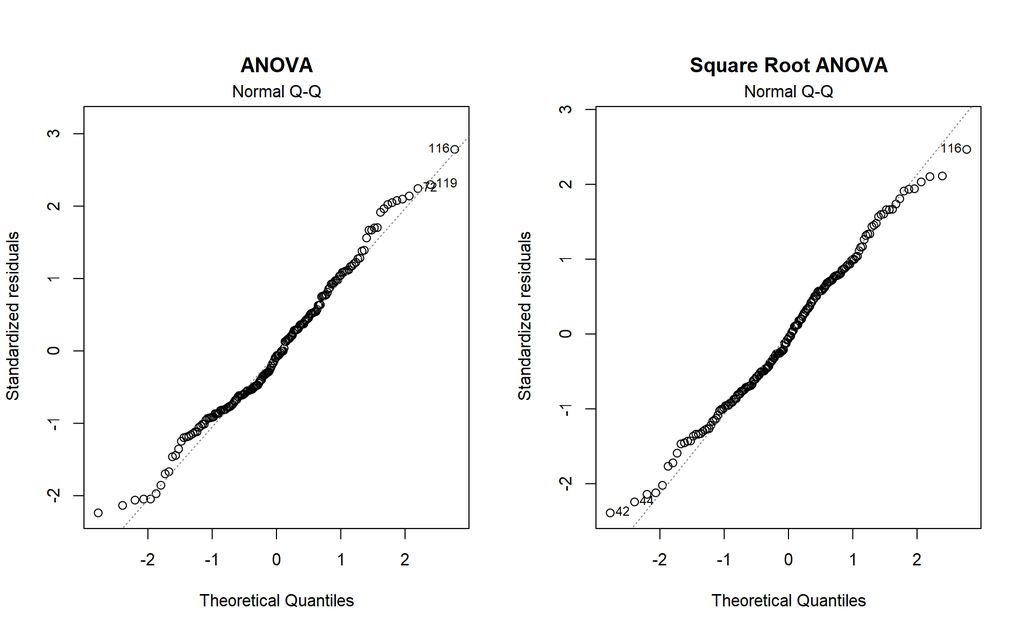

```r
par(mfrow = c(1, 2), oma = c(0, 0, 1.1, 0))
plot(anova.biomass, main = "ANOVA", which = 2, ask = F,sub.caption = "")
plot(anova.biomass.sqrt, main = "Square Root ANOVA", which = 2, ask = F,sub.caption = "")
```

Figure 20 Normality of Residuals Percentage of Biomass

```r
#AIC and BIC Biomass
AIC(anova.biomass, anova.biomass.sqrt)
```

```
##                    df       AIC
## anova.biomass       7 1214.6216
## anova.biomass.sqrt  7  387.9373
```

```r
BIC(anova.biomass, anova.biomass.sqrt)
```

```
##                    df      BIC
## anova.biomass       7 1236.972
## anova.biomass.sqrt  7  410.288
```

**2.2 Yield of Potato**

Taking into account the Tukey test for the yield of potato, first, we can see that the both cultivars produced more in 2015 than in 2016. In the case of the cultivar Svitanok kievski, the treatment BZR 336g proved to be the most efficient, and the treatment BZR 517 an intermediary when compared to the control. In the case of the Yuna cultivar, there was no statistical difference between the two treatments, however both were more efficient when compared to the control.

```r
#Duncan Yield 2015 Svitanok kievskiy
YieldOfPotato$Cultivar <- factor(YieldOfPotato$Cultivar)
Con <- YieldOfPotato$Cultivar == "Svitanok kievskiy" & YieldOfPotato$Year==2015
d1 <- YieldOfPotato[Con,]

model<-aov(Yield.Potato~Treatment,data=d1)
out <- duncan.test(model,"Treatment",
                   main="Yield of potato")
#plot(out,variation="IQR")
out$groups$groups

letter1 <- character()
letter1 <- c(letter1,out$groups$groups)


#Duncan Yield 2015 Yuna
YieldOfPotato$Cultivar <- factor(YieldOfPotato$Cultivar)
Con1 <- YieldOfPotato$Cultivar == "Yuna" & YieldOfPotato$Year==2015
d2 <- YieldOfPotato[Con1,]

model<-aov(Yield.Potato~Treatment,data=d2)
out <- duncan.test(model,"Treatment",
                   main="Yield of potato")
#plot(out,variation="IQR")
out
letter1 <- c(letter1,out$groups$groups)

#Duncan Yield 2016 Svitanok kievskiy
YieldOfPotato$Cultivar <- factor(YieldOfPotato$Cultivar)
Con1234 <- YieldOfPotato$Cultivar == "Svitanok kievskiy" & YieldOfPotato$Year==2016
d1234 <- YieldOfPotato[Con1234,]

model<-aov(Yield.Potato~Treatment,data=d1234)
out <- duncan.test(model,"Treatment",
                   main="Yield of potato")
#plot(out,variation="IQR")
out
letter1 <- c(letter1,out$groups$groups)

#Duncan Yield 2016 Yuna
YieldOfPotato$Cultivar <- factor(YieldOfPotato$Cultivar)
Con12345 <- YieldOfPotato$Cultivar == "Yuna" & YieldOfPotato$Year==2016
d2345 <- YieldOfPotato[Con12345,]

model<-aov(Yield.Potato~Treatment,data=d2345)
out <- duncan.test(model,"Treatment",
                   main="Yield of potato")
#plot(out,variation="IQR")
out
letter1 <- c(letter1,out$groups$groups)

#Tukey Yield 2015 Svitanok kievskiy
YieldOfPotato$Cultivar <- factor(YieldOfPotato$Cultivar)
Con0 <- YieldOfPotato$Cultivar == "Svitanok kievskiy" & YieldOfPotato$Year==2015
t1 <- YieldOfPotato[Con0,]

model<-aov(Yield.Potato~Treatment,data=t1)
out1 <- HSD.test(model,"Treatment", console =TRUE)
out1$groups$groups

lettert <- character()
lettert <- c(lettert,out1$groups$groups)


#Tukey Yield 2015 Yuna
YieldOfPotato$Cultivar <- factor(YieldOfPotato$Cultivar)
Con10 <- YieldOfPotato$Cultivar == "Yuna" & YieldOfPotato$Year==2015
t2 <- YieldOfPotato[Con10,]

model<-aov(Yield.Potato~Treatment,data=t2)
out1 <- HSD.test(model,"Treatment", console =TRUE)
lettert <- c(lettert,out1$groups$groups)


#Tukey Yield 2016 Svitanok kievskiy
YieldOfPotato$Cultivar <- factor(YieldOfPotato$Cultivar)
Cont <- YieldOfPotato$Cultivar == "Svitanok kievskiy" & YieldOfPotato$Year==2016
t3 <- YieldOfPotato[Cont,]

model<-aov(Yield.Potato~Treatment,data=t3)
out1 <- HSD.test(model,"Treatment", console =TRUE)
lettert <- c(lettert,out1$groups$groups)

#Tukey Yield 2016 Yuna
YieldOfPotato$Cultivar <- factor(YieldOfPotato$Cultivar)
Con12345 <- YieldOfPotato$Cultivar == "Yuna" & YieldOfPotato$Year==2016
t4 <- YieldOfPotato[Con12345,]

model<-aov(Yield.Potato~Treatment,data=t4)
out1 <- HSD.test(model,"Treatment", console =TRUE)
lettert <- c(lettert,out1$groups$groups)


#Kruskal Yield 2015 Svitanok kievskiy
YieldOfPotato$Cultivar <- factor(YieldOfPotato$Cultivar)
Con0 <- YieldOfPotato$Cultivar == "Svitanok kievskiy" & YieldOfPotato$Year==2015
k1 <- YieldOfPotato[Con0,]

kw <- kruskal(k1$Yield.Potato, k1$Treatment)
kw$groups

letterk <- character()
letterk <- c(letterk,out1$groups$groups)


#Kruskal Yield 2015 Yuna
YieldOfPotato$Cultivar <- factor(YieldOfPotato$Cultivar)
Con10 <- YieldOfPotato$Cultivar == "Yuna" & YieldOfPotato$Year==2015
k2 <- YieldOfPotato[Con10,]

kw <- kruskal(k2$Yield.Potato, k2$Treatment)
kw$groups

letterk <- c(letterk,out1$groups$groups)


#Kruskal Yield 2016 Svitanok kievskiy
YieldOfPotato$Cultivar <- factor(YieldOfPotato$Cultivar)
Cont <- YieldOfPotato$Cultivar == "Svitanok kievskiy" & YieldOfPotato$Year==2016
k3 <- YieldOfPotato[Cont,]

kw <- kruskal(k3$Yield.Potato, k3$Treatment)
kw$groups

letterk <- c(letterk,out1$groups$groups)

#Kruskal Yield 2016 Yuna
YieldOfPotato$Cultivar <- factor(YieldOfPotato$Cultivar)
Con12345 <- YieldOfPotato$Cultivar == "Yuna" & YieldOfPotato$Year==2016
k4 <- YieldOfPotato[Con12345,]

kw <- kruskal(k4$Yield.Potato, k4$Treatment)
kw$groups

letterk <- c(letterk,out1$groups$groups)
```

```r
library(ggplot2)
library(ggpubr)
#Duncan Yield Graph
#Create data frame
dat_text <- data.frame(
  label = letter1,
  Year   = c(rep(2015,6),rep(2016,6)),
  Treatment = rep(levels(as.factor(YieldOfPotato$Treatment)),4),
  Cultivar= c("Svitanok kievskiy","Svitanok kievskiy","Svitanok kievskiy","Yuna","Yuna","Yuna","Svitanok kievskiy","Svitanok kievskiy","Svitanok kievskiy","Yuna","Yuna","Yuna"))
```

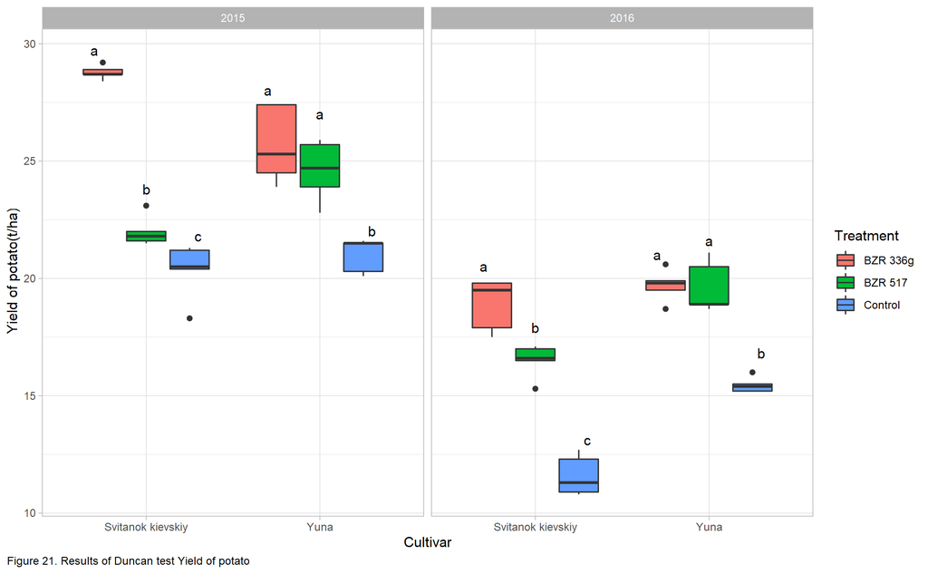

```r
duncanyieldgraph <- ggplot(YieldOfPotato, aes(x=`Cultivar`, y=Yield.Potato, fill=Treatment))+ylab("Yield of potato(t/ha)")+
  geom_boxplot()+
  facet_grid(.~Year)+
  theme_light()+
  geom_text(data = dat_text,
            mapping = aes(x = Cultivar,
                          y = c(29.7, 23.8,21.8, 28,27,22,20.5,17.9,13.1,21,21.6,16.8),
                          label = letter1),
            position = position_dodge(0.9))+
  labs(caption = "Figure 21. Results of Duncan test Yield of potato") +
  theme(plot.caption.position = "plot",
        plot.caption = element_text(hjust = 0))
duncanyieldgraph
```

```r
#Tukey Yield Graph
#Create data frame
dat_text1 <- data.frame(
  label = lettert,
  Year   = c(rep(2015,6),rep(2016,6)),
  Treatment = rep(levels(as.factor(YieldOfPotato$Treatment)),4),
  Cultivar= c("Svitanok kievskiy","Svitanok kievskiy","Svitanok kievskiy","Yuna","Yuna","Yuna","Svitanok kievskiy","Svitanok kievskiy","Svitanok kievskiy","Yuna","Yuna","Yuna"))
```

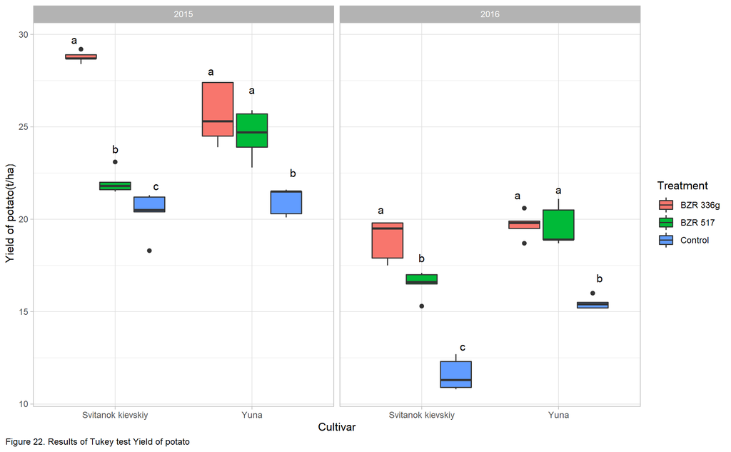

```r
tukeyyieldgraph <- ggplot(YieldOfPotato, aes(x=`Cultivar`, y=Yield.Potato, fill=Treatment))+ylab("Yield of potato(t/ha)")+
  geom_boxplot()+
  facet_grid(.~Year)+
  theme_light()+
  geom_text(data = dat_text1,
            mapping = aes(x = Cultivar,
                          y = c(29.7, 23.8,21.8, 28,27,22.5,20.5,17.9,13.1,21.3,21.6,16.8),
                          label = lettert),
            position = position_dodge(0.9))+
  labs(caption = "Figure 22. Results of Tukey test Yield of potato") +
  theme(plot.caption.position = "plot",
        plot.caption = element_text(hjust = 0))
tukeyyieldgraph
```

```r
#Kruskal Yield Graph
#Create data frame
dat_textk <- data.frame(
  label = letterk,
  Year   = c(rep(2015,6),rep(2016,6)),
  Treatment = rep(levels(as.factor(YieldOfPotato$Treatment)),4),
  Cultivar= c("Svitanok kievskiy","Svitanok kievskiy","Svitanok kievskiy","Yuna","Yuna","Yuna","Svitanok kievskiy","Svitanok kievskiy","Svitanok kievskiy","Yuna","Yuna","Yuna"))
```

[figure not shown]

```r
kruskalyieldgraph <- ggplot(YieldOfPotato, aes(x=`Cultivar`, y=Yield.Potato, fill=Treatment))+ylab("Yield of potato(t/ha)")+
  geom_boxplot()+
  facet_grid(.~Year)+
  theme_light()+
  geom_text(data = dat_textk,
            mapping = aes(x = Cultivar,
                          y = c(29.7, 23.8,21.8, 28,27,22,20.5,17.9,13.1,21,21.6,16.8),
                          label = letter1),
            position = position_dodge(0.9))+
  labs(caption = "Figure 23. Results of Kruskal test Yield of potato") +
  theme(plot.caption.position = "plot",
        plot.caption = element_text(hjust = 0))
kruskalyieldgraph
```

```r
#Residuals

#Residuals Yield 2015 Svitanok kievskiy
YieldOfPotato$Cultivar <- factor(YieldOfPotato$Cultivar)
Con <- YieldOfPotato$Cultivar == "Svitanok kievskiy" & YieldOfPotato$Year==2015
d1 <- YieldOfPotato[Con,]
anova.yieldsk<-aov(Yield.Potato~Treatment,data=d1) #anova
anova.yieldsk.sqrt <- aov(sqrt(Yield.Potato)~Treatment,data=d1) #square root
shapiro.test(anova.yieldsk$residuals) #0.0553
```

```
##
##  Shapiro-Wilk normality test
##
## data:  anova.yieldsk$residuals
## W = 0.88445, p-value = 0.0553
```

```r
#shapiro.test(anova.yieldsk.sqrt$residuals) #0.02795

#Residuals Yield 2015 Yuna
YieldOfPotato$Cultivar <- factor(YieldOfPotato$Cultivar)
Con1 <- YieldOfPotato$Cultivar == "Yuna" & YieldOfPotato$Year==2015
d2 <- YieldOfPotato[Con1,]
anova.yieldy<-aov(Yield.Potato~Treatment,data=d2)#anova
anova.yieldy.sqrt <- aov(sqrt(Yield.Potato)~Treatment,data=d2) #square root
shapiro.test(anova.yieldy$residuals) #0.4242
```

```
##
##  Shapiro-Wilk normality test
##
## data:  anova.yieldy$residuals
## W = 0.94319, p-value = 0.4242
```

```r
#shapiro.test(anova.yieldy.sqrt$residuals) #0.3887

#Residuals Yield 2016 Svitanok kievskiy
YieldOfPotato$Cultivar <- factor(YieldOfPotato$Cultivar)
Con1234 <- YieldOfPotato$Cultivar == "Svitanok kievskiy" & YieldOfPotato$Year==2016
d1234 <- YieldOfPotato[Con1234,]
anova.yieldsk6<-aov(Yield.Potato~Treatment,data=d1234)#anova
anova.yieldsk6.sqrt <- aov(sqrt(Yield.Potato)~Treatment,data=d1234)#square root
shapiro.test(anova.yieldsk6$residuals) #0.1674
```

```
##
##  Shapiro-Wilk normality test
##
## data:  anova.yieldsk6$residuals
## W = 0.916, p-value = 0.1674
```

```r
#shapiro.test(anova.yieldsk6.sqrt$residuals) #0.1481

#Residuals Yield 2016 Yuna
YieldOfPotato$Cultivar <- factor(YieldOfPotato$Cultivar)
Con12345 <- YieldOfPotato$Cultivar == "Yuna" & YieldOfPotato$Year==2016
d2345 <- YieldOfPotato[Con12345,]
anova.yieldy6<-aov(Yield.Potato~Treatment,data=d2345) #anova
anova.yieldy6.sqrt <- aov(sqrt(Yield.Potato)~Treatment,data=d2345) #square root
shapiro.test(anova.yieldy6$residuals) #0.6108
```

```
##
##  Shapiro-Wilk normality test
##
## data:  anova.yieldy6$residuals
## W = 0.95526, p-value = 0.6108
```

```r
#shapiro.test(anova.yieldy6.sqrt$residuals) #0.6299
```

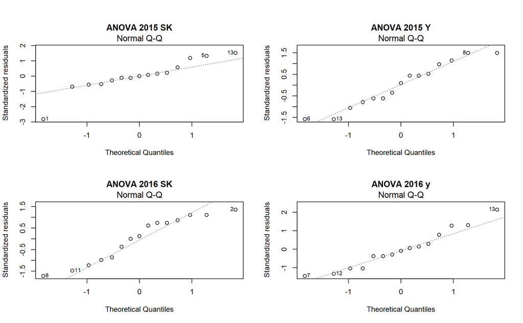

```r
#Graph
par(mfrow = c(2, 2), oma = c(0, 0, 1.1, 0))
p1 <- plot(anova.yieldsk, main = "ANOVA 2015 SK", which = 2, ask = F,sub.caption = "")
p2 <- plot(anova.yieldy, main = "ANOVA 2015 Y", which = 2, ask = F,sub.caption = "")
p3 <- plot(anova.yieldsk6, main = "ANOVA 2016 SK", which = 2, ask = F,sub.caption = "")
p4 <- plot(anova.yieldy6, main = "ANOVA 2016 y", which = 2, ask = F,sub.caption = "")
```

Figure 24. Normality of Residuals Yield of Potato

**3) *In vitro* antifungal activity of *Bacillus strains* against the phytopathogenic fungus *R. solani*, isolated from infected potato tubers**

**3.1 Growth of the diameter of the colonies of *R. solani* under the influence of *B. velezensis* after 3, 5 and 7 days**

Clear differences were observed over time between the colonial growth of *R. solani* under the effect of different treatments with *B. velezensis* and the control (Figure 25). All treatments showed lower initial colonial growth (day 3) compared to the control, also they showed a progressive growth in colony diameter at day 5 and 7. Treatment BZR 517 10e+06 is the only one that shows a decrease in colonial growth at day 7 compared to day 5.

```r
##### 1. ANTAGONISTIC ACTIVITY

#### Antagonistic activity was evaluated by measuring the diameter of the fungal
#### colonies after 3, 5, and 7 days. The fungal inhibition (%) was determined
#### based on the data obtained.

#### All results were expressed and analyzed as the mean.

#### 1.1 Mean and Standard error for Fungal diameter for each treatment.

## Creating a new plot with means and standard errors

#install.packages("dplyr")

library("dplyr")

plot.means <- AntagonisticActivity %>%
  group_by(Days,Trat) %>%
  summarize(n = n(),
            mean = mean(Colony.Diameter),
            sd = sd(Colony.Diameter),
            se = sd / sqrt(n))
```

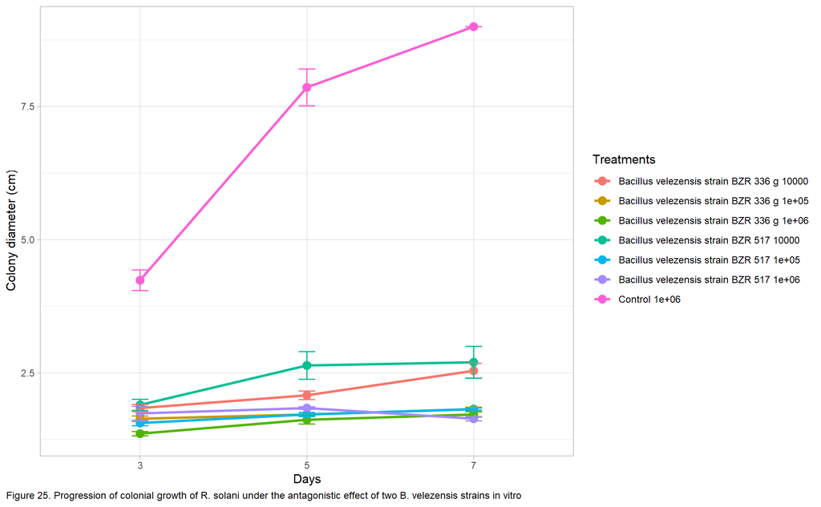

```r
##Graph the influence of treatments on the fungal diameter growth after 3, 5 and 7 days.

#install.packages("ggplot2")

library(ggplot2)

ggplot(plot.means, aes(x = Days,
                       y = mean,
                       group=Trat,
                       color=Trat)) +
  geom_point(size = 3) +
  geom_line(size = 1) +
  geom_errorbar(aes(ymin=mean-se,
                    ymax=mean+se),
                width = .1)+
  labs(caption = "Figure 25. Progression of colonial growth of R. solani under the antagonistic effect of two B. velezensis strains in vitro",
       x = "Days",
       y = "Colony diameter (cm)",
       color = "Treatment") +theme_light()+ guides(col=guide_legend("Treatments")) +
  theme(plot.caption.position = "plot",
        plot.caption = element_text(hjust = 0))
```

**3.2 Inhibition of the growth of *R. solani* under the influence of different *B. velezensis* treatments after 3, 5 and 7 days *in vitro***

The studied *B. velezensis* strains BZR 336 g and BZR 517 inhibited the growth of *R. solani* under laboratory conditions. The inhibition ratio depended on the concentration of *B. velezensis* in the nutrient medium, and it showed a decrease over time.

For determining the treatments with the best performance at day 3, 5 and 7, multiple comparison of means was performed by using Duncan’s non-parametric test, according with authors’ method. In addition, Tukey’s parametric test and Kruskal-Wallis non-parametric test were performed to know the different groupings among analyzes.

The Shapiro-Wilk normality test was performed for ANOVA, the p values at 3, 5 and 7 days were less than alpha=0.05, which means that the null hypothesis that the data are normally distributed is rejected (Figure 29). Since the data does not follow a normal distribution, the most appropriate is to perform non-parametric tests, which does not assume normality. This is consistent with the authors’ decision to analyze the data with Duncan’s test, and also strengthens our decision to perform another non-parametric test, Kruskal-Wallis, which is considered more robust. Even if data is not normal, ANOVA test should be still performed.

For days 3, 5 and 7 there were significant differences between treatments. In an overall perspective, only few differences were found between Duncan, Tukey and Kruskal-Wallis groupings (Figures 26, 27, and 28).

On day 3, data grouping showed significant differences between the treatments and the control, while the differences between treatments were not clear enough to make conjectures. Data clustered differently across tests, showing differences. Control showed a fungal colony diameter (FCD) of 4.24 cm.

On day 5, there were significant differences between the treatments and the control, also there were significant differences between treatments. Data clustered very similarly across tests, showing only very few differences. All tests agreed that the treatments with the high concentration (10^6 CFU/mL) of BZR 336 g and medium concentrations (10^5 CFU/mL) of both strains (BZR 336 g and BZR 517) had the best performance with FCD of 1.62 and 1.72 cm, respectively. Control showed a fungal FCD of 7.86 cm.

On day 7, there were significant differences between the treatments and the control, and also between treatments. Data clustered equally across tests, showing no differences. All tests agreed that treatments with high (10^6 CFU/mL) and medium (10^5 CFU/mL) concentration of both strains (BZR 517 and BZR 336 g) had the best performance with FCD of 1.64, 1.72, 1.82 and 1.82 cm, respectively. Control showed a fungal FCD of 9 cm.

Only treatment BZR 517 at its higher concentration (10^6 CFU/mL) showed a decrease in FCD on day 7 in comparison with day 5. The rest of the treatments showed a progressive increment of FCD over time.

```r
#### 1.2 Statistical Analysis

### 1.2.1 Duncan, ANOVA and Kruskal-Wallis test

### Multiple comparisons of the means were performed by using Duncan, ANOVA and
### Kruskal-Wallis test with a significance level of p = 0.05.

## Duncan analysis for Fungal colony diameter at 3 d
library ("agricolae")
Dia <- 3

AntagonisticActivity$Days <- factor(AntagonisticActivity$Days)
Y1 <- AntagonisticActivity$Days==Dia
AA <- AntagonisticActivity[Y1,]

model <- aov(Colony.Diameter~Trat,data=AA)
out <- duncan.test(model,"Trat",main = "Colony diameter")
out

#plot(out,variation="IQR")

## Tukey analysis for Fungal colony diameter at 3 d

out.hsd <- HSD.test(model,"Trat",console = TRUE)

## Kruskal-Wallis analysis for Fungal colony diameter at 3 d

library(agricolae)

kw.3d<-with(AA,kruskal(Colony.Diameter,Trat,group=TRUE, main=NULL, console = TRUE))

## Duncan analysis for Fungal colony diameter at 5 d
Dia <- 5

AntagonisticActivity$Days <- factor(AntagonisticActivity$Days)
Y1 <- AntagonisticActivity$Days==Dia
AA <- AntagonisticActivity[Y1,]

model <- aov(Colony.Diameter~Trat,data=AA)
out <- duncan.test(model,"Trat",main = "Colony diameter")
out

#plot(out,variation="IQR")

## Tukey analysis for Fungal colony diameter at 5 d

out.hsd <- HSD.test(model,"Trat",console = TRUE)

## Kruskal-Wallis analysis for Fungal colony diameter at 5 d

library(agricolae)

kw.5d<-with(AA,kruskal(Colony.Diameter,Trat,group=TRUE, main=NULL, console = TRUE))

## Duncan analysis for Fungal colony diameter at 7 d
Dia <- 7

AntagonisticActivity$Days <- factor(AntagonisticActivity$Days)
Y1 <- AntagonisticActivity$Days==Dia
AA <- AntagonisticActivity[Y1,]

model <- aov(Colony.Diameter~Trat,data=AA)
out <- duncan.test(model,"Trat",main = "Colony diameter")
out

## Tukey analysis for Fungal colony diameter at 7 d

out.hsd <- HSD.test(model,"Trat",console = TRUE)

## Kruskal-Wallis analysis for Fungal colony diameter at 7 d

library(agricolae)

kw.7d<-with(AA,kruskal(Colony.Diameter,Trat,group=TRUE, main=NULL, console = TRUE))
```

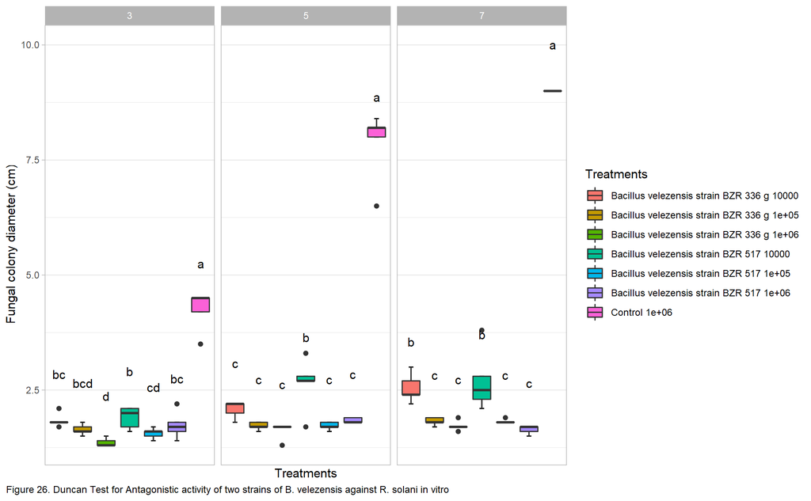

```r
## Combine Duncan graphs for 3, 5 and 7 d

#library(ggplot2)
#library(ggpubr)
#theme_set(theme_pubr())

DunLetters <- data.frame(Days=c(rep(3,7),rep(5,7),rep(7,7)),
                         Trat=c("Bacillus velezensis strain BZR 336 g 10000","Bacillus velezensis strain BZR 336 g 1e+05",
                                "Bacillus velezensis strain BZR 336 g 1e+06","Bacillus velezensis strain BZR 517 10000",
                                "Bacillus velezensis strain BZR 517 1e+05","Bacillus velezensis strain BZR 517 1e+06",
                                "Control 1e+06","Bacillus velezensis strain BZR 336 g 10000","Bacillus velezensis strain BZR 336 g 1e+05",
                                "Bacillus velezensis strain BZR 336 g 1e+06","Bacillus velezensis strain BZR 517 10000",
                                "Bacillus velezensis strain BZR 517 1e+05","Bacillus velezensis strain BZR 517 1e+06",
                                "Control 1e+06","Bacillus velezensis strain BZR 336 g 10000","Bacillus velezensis strain BZR 336 g 1e+05",
                                "Bacillus velezensis strain BZR 336 g 1e+06","Bacillus velezensis strain BZR 517 10000",
                                "Bacillus velezensis strain BZR 517 1e+05","Bacillus velezensis strain BZR 517 1e+06",
                                "Control 1e+06"),
                         Mean=plot.means$mean,
                         SE=plot.means$se,
                         label=c("bc","bcd","d","b","cd","bc","a","c","c","c","b","c","c","a","b","c","c","b","c","c","a"))

DunBox <- ggplot(AntagonisticActivity, aes(x=`Trat`, y=Colony.Diameter, fill=Trat))+xlab("Treatments")+ylab("Fungal colony diameter (cm)")+
  stat_boxplot(geom = "errorbar",
               width = 0.2) +
  geom_boxplot()+
  theme_light()+
  geom_text(data = DunLetters,
            mapping = aes(x = Trat,
                          y = Mean+1,
                          label=label),
            position = position_dodge(0.9))+
  facet_grid(.~Days)+
  labs(caption = "Figure 26. Duncan Test for Antagonistic activity of two strains of B. velezensis against R. solani in vitro") +
  scale_x_discrete(("Treatments"),limitedLabels("Treatments"))+
  scale_fill_discrete(("Treatments"))+
  theme(plot.caption.position = "plot",
        plot.caption = element_text(hjust = 0))

DunBox
```

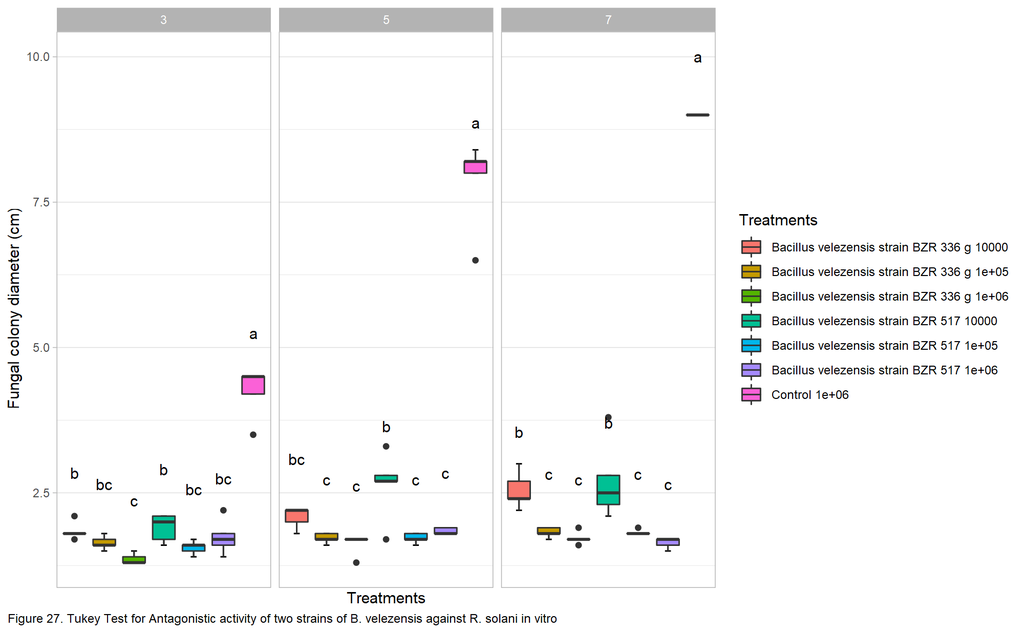

```r
## Tukey graphs for 3, 5 and 7 d

#library(ggplot2)
#library(ggpubr)
#theme_set(theme_pubr())

TukLetters <- data.frame(Days=c(rep(3,7),rep(5,7),rep(7,7)),
                         Trat=c("Bacillus velezensis strain BZR 336 g 10000","Bacillus velezensis strain BZR 336 g 1e+05",
                                "Bacillus velezensis strain BZR 336 g 1e+06","Bacillus velezensis strain BZR 517 10000",
                                "Bacillus velezensis strain BZR 517 1e+05","Bacillus velezensis strain BZR 517 1e+06",
                                "Control 1e+06","Bacillus velezensis strain BZR 336 g 10000","Bacillus velezensis strain BZR 336 g 1e+05",
                                "Bacillus velezensis strain BZR 336 g 1e+06","Bacillus velezensis strain BZR 517 10000",
                                "Bacillus velezensis strain BZR 517 1e+05","Bacillus velezensis strain BZR 517 1e+06",
                                "Control 1e+06","Bacillus velezensis strain BZR 336 g 10000","Bacillus velezensis strain BZR 336 g 1e+05",
                                "Bacillus velezensis strain BZR 336 g 1e+06","Bacillus velezensis strain BZR 517 10000",
                                "Bacillus velezensis strain BZR 517 1e+05","Bacillus velezensis strain BZR 517 1e+06",
                                "Control 1e+06"),
                         Mean=plot.means$mean,
                         SE=plot.means$se,
                         label=c("b","bc","c","b","bc","bc","a","bc","c","c","b","c","c","a","b","c","c","b","c","c","a"))

TukBox <- ggplot(AntagonisticActivity, aes(x=`Trat`, y=Colony.Diameter, fill=Trat))+xlab("Treatments")+ylab("Fungal colony diameter (cm)")+
  stat_boxplot(geom = "errorbar",
               width = 0.2) +
  geom_boxplot()+
  theme_light()+
  geom_text(data = TukLetters,
            mapping = aes(x = Trat,
                          y = Mean+1,
                          label=label),
            position = position_dodge(0.9))+
  facet_grid(.~Days)+
  labs(caption = "Figure 27. Tukey Test for Antagonistic activity of two strains of B. velezensis against R. solani in vitro") +
  scale_x_discrete(("Treatments"),limitedLabels("Treatments"))+
  scale_fill_discrete(("Treatments"))+
  theme(plot.caption.position = "plot",
        plot.caption = element_text(hjust = 0))

TukBox
```

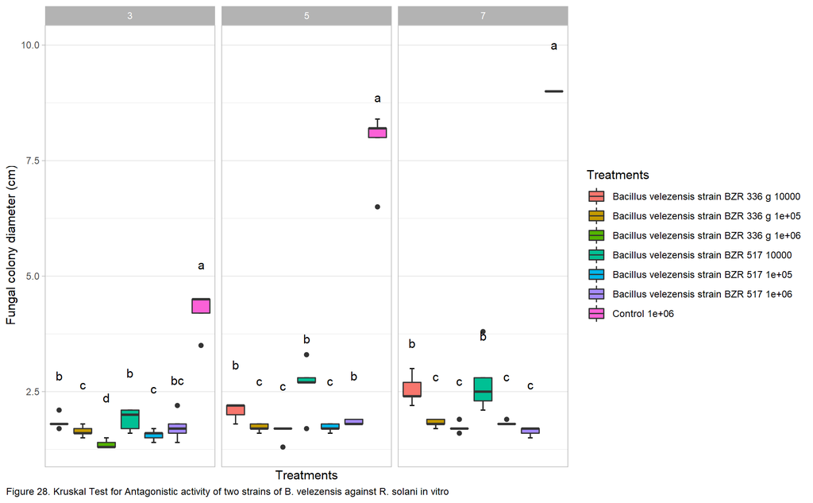

```r
## Kruskal-Wallis graphs for 3, 5 and 7 d

library(ggplot2)
library(ggpubr)
theme_set(theme_pubr())

KWLetters <- data.frame(Days=c(rep(3,7),rep(5,7),rep(7,7)),
                         Trat=c("Bacillus velezensis strain BZR 336 g 10000","Bacillus velezensis strain BZR 336 g 1e+05",
                                "Bacillus velezensis strain BZR 336 g 1e+06","Bacillus velezensis strain BZR 517 10000",
                                "Bacillus velezensis strain BZR 517 1e+05","Bacillus velezensis strain BZR 517 1e+06",
                                "Control 1e+06","Bacillus velezensis strain BZR 336 g 10000","Bacillus velezensis strain BZR 336 g 1e+05",
                                "Bacillus velezensis strain BZR 336 g 1e+06","Bacillus velezensis strain BZR 517 10000",
                                "Bacillus velezensis strain BZR 517 1e+05","Bacillus velezensis strain BZR 517 1e+06",
                                "Control 1e+06","Bacillus velezensis strain BZR 336 g 10000","Bacillus velezensis strain BZR 336 g 1e+05",
                                "Bacillus velezensis strain BZR 336 g 1e+06","Bacillus velezensis strain BZR 517 10000",
                                "Bacillus velezensis strain BZR 517 1e+05","Bacillus velezensis strain BZR 517 1e+06",
                                "Control 1e+06"),
                         Mean=plot.means$mean,
                         SE=plot.means$se,
                         label=c("b","c","d","b","c","bc","a","b","c","c","b","c","b","a","b","c","c","b","c","c","a"))

KWBox <- ggplot(AntagonisticActivity, aes(x=`Trat`, y=Colony.Diameter, fill=Trat))+xlab("Treatments")+ylab("Fungal colony diameter (cm)")+
  stat_boxplot(geom = "errorbar",
               width = 0.2) +
  geom_boxplot()+
  theme_light()+
  geom_text(data = KWLetters,
            mapping = aes(x = Trat,
                          y = Mean+1,
                          label=label),
            position = position_dodge(0.9))+
  facet_grid(.~Days)+
  labs(caption = "Figure 28. Kruskal Test for Antagonistic activity of two strains of B. velezensis against R. solani in vitro") +
  scale_x_discrete(("Treatments"),limitedLabels("Treatments"))+
  scale_fill_discrete(("Treatments"))+
  theme(plot.caption.position = "plot",
        plot.caption = element_text(hjust = 0))

KWBox
```

```r
## Residuals for Antagonistic activity

##Residuals for day 3
library ("agricolae")
Dia <- 3

AntagonisticActivity$Days <- factor(AntagonisticActivity$Days)
Y1 <- AntagonisticActivity$Days==Dia
AA <- AntagonisticActivity[Y1,]

anova.3d <- aov(Colony.Diameter~Trat,data=AA) #anova
anova.3d.sqrt <- aov(sqrt(Colony.Diameter)~Trat,data=AA) #square root
shapiro.test(anova.3d$residuals) #0.01891
```

```
##
##  Shapiro-Wilk normality test
##
## data:  anova.3d$residuals
## W = 0.92423, p-value = 0.01891
```

```r
shapiro.test(anova.3d.sqrt$residuals) #0.3884
```

```
##
##  Shapiro-Wilk normality test
##
## data:  anova.3d.sqrt$residuals
## W = 0.96791, p-value = 0.3884
```

```r
##Residuals for day 5
library ("agricolae")
Dia <- 5

AntagonisticActivity$Days <- factor(AntagonisticActivity$Days)
Y1 <- AntagonisticActivity$Days==Dia
AA <- AntagonisticActivity[Y1,]

anova.5d <- aov(Colony.Diameter~Trat,data=AA) #anova
anova.5d.sqrt <- aov(sqrt(Colony.Diameter)~Trat,data=AA) #square root
shapiro.test(anova.5d$residuals) #1.646 e-06
```

```
##
##  Shapiro-Wilk normality test
##
## data:  anova.5d$residuals
## W = 0.73985, p-value = 1.646e-06
```

```r
shapiro.test(anova.5d.sqrt$residuals) #1.099 e-05
```

```
##
##  Shapiro-Wilk normality test
##
## data:  anova.5d.sqrt$residuals
## W = 0.78604, p-value = 1.099e-05
```

```r
##Residuals for day 7
library ("agricolae")
Dia <- 7

AntagonisticActivity$Days <- factor(AntagonisticActivity$Days)
Y1 <- AntagonisticActivity$Days==Dia
AA <- AntagonisticActivity[Y1,]

anova.7d <- aov(Colony.Diameter~Trat,data=AA) #anova
anova.7d.sqrt <- aov(sqrt(Colony.Diameter)~Trat,data=AA) #square root
shapiro.test(anova.7d$residuals) #3.084 e-06
```

```
##
##  Shapiro-Wilk normality test
##
## data:  anova.7d$residuals
## W = 0.7557, p-value = 3.084e-06
```

```r
shapiro.test(anova.7d.sqrt$residuals) #2.288 e-05
```

```
##
##  Shapiro-Wilk normality test
##
## data:  anova.7d.sqrt$residuals
## W = 0.80253, p-value = 2.288e-05
```

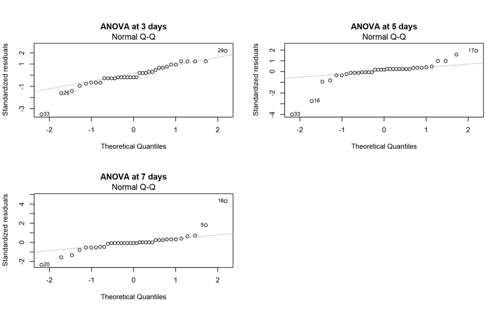

```r
#Graph
par(mfrow = c(2, 2), oma = c(0, 0, 1.1, 0))
p1 <- plot(anova.3d, main = "ANOVA at 3 days", which = 2, ask = F,sub.caption = "")
p2 <- plot(anova.5d, main = "ANOVA at 5 days", which = 2, ask = F,sub.caption = "")
p3 <- plot(anova.7d, main = "ANOVA at 7 days", which = 2, ask = F,sub.caption = "")
```

Figure 29. Normality of Residuals for Antagonistic activity

## Conclusions

It can be considered that our data sample is relatively small (1 plant per plot, with 5 repetitions). For potato crop evaluations, some studies recommend smaller plots with a greater number of repetitions in the same total area result in greater precision (Ribeiro et al, 2005). Also Ribeiro et al (2005) estimated an optimum plot size of (4) mounds per treatment for potato yield crop, and a great number or repetitions. Muzhinji et al (2018) recommend to sample 10 plants per plot/treatment with 4 repetitions for evaluating *R. solani* in potato crop.

From the observation that some data sets do not follow a normal distribution, it can be inferred that the authors performed non parametric Duncan test, since this can be applied in the same conditions of the Tukey’s test, but with a significance less cautionary. Also in the argument that a more liberal procedure is appropriate because in real world practice the global null hypothesis Ho = “All means are equal” is often false. Due to the lack of robustness of Duncan’s test there are some cautions to follow, as many times it cannot be accepted as a proof of differences.

We performed Tukey (parametric) and Kruskal-Wallis (non parametric) in addition to Duncan test, to provide more robust analyzes. Tukey, is more conservative and therefore “less objectionable”. When ANOVA assumptions are not met, it is recommended to perform Kruskal-Wallis test, which is an alternative to ANOVA when there are more than two groups to compare. Also Kruskal-Wallis test tends to be more robust and therefore more accepted in scientific publications.

The studied strains (BZR 336 g and BZR 517) were effective reducing the incidence and severity of *R. solani* on potato plants under yield conditions. *B. velezensis* strains improved plant height, number of stems per plant and increased the yield. Also the use of these strains improve the % of medium and large tubers. *B. velezensis* strains had an inhibitory effect in the *R. solani* colony growth under laboratory conditions. For yield trials, the strain BZR 336 g showed the best performance, while high concentrations of both strains performed the best inhibitory effect in laboratory.

It will be interesting to compare the B. velezensis effect with the performance of the current R. solani disease management.

## References

Muzhinji, N., Woodhall, j. W., Truter, M., and Van der Waals, J. E. (2017). Relative Contribution of Seed Tuber- and Soilborne Inoculum to Potato Disease Development and Changes in the Population Genetic Structure of Rhizoctonia solani AG 3-PT under Field Conditions in South Africa. https://doi.org/10.1094/PDIS-03-17-0329-RE

Ribeiro de Oliveira, S. J., Storck, L. Sidinei, J. L., A., Dal’Col, L. A., Feijó, S. and Perin, D. H. (2005). Plot size and experimental unit relationship in exploratory experiments. https://doi.org/10.1590/S0103-90162005000600012